# CTA1 promoter bashing

JY

2023-11-24 (updated 2024-07-16)

```r
library(tidyverse)
library(ggtext)
#library(mgcv)
library(broom)
library(cowplot)
library(ggpattern)
library(RColorBrewer)
```

## Goal

Plot the dynamics for CTA1 promoter bashing variants under - Pi and 2 mM H2O2 treatment

## Common plotting functions

**Update 2022-11-08** This list is used as a shared plotting set up.

```r
p.timecourse <- list(
  stat_summary(fun = "mean", geom = "point", size = 3),
  stat_summary(fun.data = "mean_cl_boot", geom = "errorbar", width = 3),
  stat_smooth(aes(size = Genotype == "WT"), method = "loess",
              formula = 'y~x', se = FALSE),
  scale_x_continuous(breaks = seq(0,240,30)),
  scale_size_manual(values = c(0.8, 1.5), guide = "none"),
  labs(x = "Time (min)", y = "Cta1-GFP protein level (a.u.)"),
  theme_cowplot(line_size = 0.7, font_size = 14),
  theme(legend.position=c(0.05,0.75),
        #legend.box.background = element_rect(color = "black"),
        #legend.box.margin = margin(3,3,3,3),
        legend.text = element_text(face = 3),
        legend.title = element_text(),
        axis.title = element_text(size = rel(1)),
        #axis.title.x = element_blank(),
        axis.text.x = element_text(hjust=0.5), axis.text = element_text(size = rel(1)),
  )
)
mean.timecourse <- list(
  stat_summary(fun = "mean", geom = "point", size = 3),
  stat_smooth(aes(size = Genotype == "WT"), method = "loess",
              formula = 'y~x', se = FALSE),
  scale_x_continuous(breaks = seq(0,240,30)),
  scale_size_manual(values = c(0.8, 1.5), guide = "none"),
  labs(x = "Time (min)", y = "Cta1-GFP protein level (a.u.)"),
  theme_cowplot(line_size = 0.7, font_size = 14),
  theme(legend.position=c(0.02,0.9),
        #legend.direction = "horizontal",
        #legend.box.background = element_rect(color = "black"),
        #legend.box.margin = margin(3,3,3,3),
        legend.text = element_text(face = 3),
        legend.title = element_text(),
        axis.title = element_text(size = rel(1)),
        #axis.title.x = element_blank(),
        axis.text.x = element_text(hjust=0.5), axis.text = element_text(size = rel(1)),
  )
)



scatter <- list(stat_summary(fun = "mean", geom = "point", size = 3),
                scale_y_continuous(breaks = seq(0,1.0,0.25)),
                scale_x_continuous(breaks = seq(0,1.0,0.25)),
                scale_size_manual(values = c(0.8, 1.5), guide = "none"),
                expand_limits(x = 0, y = 0),
                theme_cowplot(line_size = 0.7, font_size = 20),
                theme(legend.position=c(0.02,0.82),
                legend.text = element_text(face = 3),
                legend.title = element_text(),
                axis.title = element_text(size = rel(1)),
                axis.text.x = element_text(hjust=0.5), axis.text = element_text(size = rel(1))))

bar.list <- list(
  stat_summary(fun.data = "mean_cl_boot", conf.int = .95, colour = "red", linewidth = 1, size = 0.8),
  scale_size_manual(values = c(0.8, 1.5), guide = "none"),
  labs(x =paste0("2mM H2O2, OL variants ", deparse1(substitute(input_tp)), " min"), y = "Cta1-GFP protein level (a.u.)"),
  theme_cowplot(line_size = 0.7, font_size = 14),
  theme(legend.position=c(0.02,0.9),
        #legend.direction = "horizontal",
        #legend.box.background = element_rect(color = "black"),
        #legend.box.margin = margin(3,3,3,3),
        legend.text = element_text(face = 3),
        legend.title = element_text(),
        axis.title = element_text(size = rel(1)),
        #axis.title.x = element_blank(),
        axis.text.x = element_text(hjust=0.5), axis.text = element_text(size = rel(1)),
  )
)
bar.list.no.stat <- list(
  #stat_summary(fun.data = "mean_cl_boot", conf.int = .95, colour = "red", linewidth = 1, size = 0.8),
  scale_size_manual(values = c(0.8, 1.5), guide = "none"),
  theme_cowplot(line_size = 0.7, font_size = 14),
  theme(legend.position=c(0.02,0.9),
        #legend.direction = "horizontal",
        #legend.box.background = element_rect(color = "black"),
        #legend.box.margin = margin(3,3,3,3),
        legend.text = element_text(face = 3),
        legend.title = element_text(),
        axis.title = element_text(size = rel(1)),
        #axis.title.x = element_blank(),
        axis.text.x = element_text(hjust=0.5), axis.text = element_text(size = rel(1)),
  )
)
```

## CTA1 induction in OL variants

#### -Pi Data

Import data and get the replicate, time and genotype info

```r
files <- dir("input/OL_0Pi", pattern = "d01*") # get the file names of the merged
files <- file.path("input//OL_0Pi", files)         # this appends the directory to the file names
names(files) <- c("Rep1-0Pi-Ctrl","Rep2-0Pi-Ctrl", "Rep3-0Pi-Ctrl")

tp <- c("0min",  "30min", "60min", "90min", "120min", "150min",  "180min", "210min", "240min") # ordered time points

# import and process the data to the format we want
data.ol.pi <- map_dfr(files, ~read_csv(., na = c("", "NA", "N/A"), col_types = cols()), .id = "Replicate") %>%
  #bind_rows(.id = "Replicate") %>%
  filter(`X Parameter` == "BL1-H", is.na(`Y Parameter`)) %>%
  select(Replicate, Group, Sample, Count, median = `X Median`, peak = `X Peak`,
         sd = `X SD`, cv = `X %CV`, rCV = `X %rCV`) %>%
  separate(Group, into = c('Time', 'Treatment'), sep = "-") %>%
  mutate(Time = ordered(Time, levels = tp)) %>%
  mutate(Sample = case_when(Sample == "CTA1-GFP-yH298" ~ "yH298-wt",
            Sample == "CTA1-GFP-yH299" ~ "yH299-wt",
            Sample == "yH343-wt" ~ "yH343-rescue",
            Sample == "yH344-wt" ~ "yH344-rescue",
            TRUE ~ Sample)) %>%
  mutate(Replicate = gsub("\\-.*","", Replicate)) %>% #
  separate(Sample, into = c("Strain", "genotype"), sep = "-") %>%
  arrange(Time)
# To replace the value: ifelse() for a single test, case_when() for multiple test
# \\-: escape character "\\" used to escape the special meaning of -, instead take - as a common regex pattern. Or we can specify the - as a regex pattern within a square bracket class [-]
#.*: This part matches any sequence of characters (.* is a common regex pattern for "any character, zero or more times"). metacharacter
```

#### under -Pi

Plot the internal removal variants data(OL)

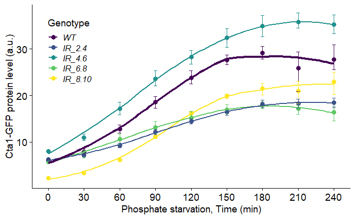

```r
# recode the genotype
levels <- c(`WT` = "wt", `PC`= "rescue",`IR_8.10` = "10OL", `IR_6.8` = "8OL", `IR_4.6` = "6OL", `IR_2.4` = "4OL")
levels.norescue <- c(`WT` = "wt",`IR_2.4` = "4OL", `IR_4.6` = "6OL", `IR_6.8` = "8OL", `IR_8.10` = "10OL")
G.levels <- c("WT", "PC", "IR_8.10", "IR_6.8", "IR_4.6", "IR_2.4")

pi.ol.dat <- data.ol.pi %>%
  filter(genotype %in% c("wt", "4OL", "6OL", "8OL", "10OL","rescue")) %>%
  select(Time, replicate = Replicate, genotype, Strain, median) %>%
  mutate(Genotype = fct_recode(genotype, !!!levels)) %>%
  mutate(new_median =median/1000) %>%
  mutate(new_time = as.numeric(gsub("min","",Time)))%>%
  arrange(new_time, genotype, replicate)%>%
  mutate(genotype = factor(genotype, levels = levels)) %>%
  mutate(Genotype = factor(Genotype, levels = G.levels)) %>%
  mutate(dP_series = fct_recode(genotype, 'WT' = "wt", 'PC' = "rescue", 'dP4' = "10OL", 'dP3' = "8OL", 'dP2' = "6OL", 'dP1' = "4OL"))

pi.ol.dat %>%
  filter(!is.na(new_median), genotype != "rescue") %>%
  ggplot(aes(x = new_time, y = new_median, color = Genotype)) + p.timecourse +
  scale_color_viridis_d(limits = names(levels.norescue))  +
  labs(x = "Phosphate starvation, Time (min)")
```

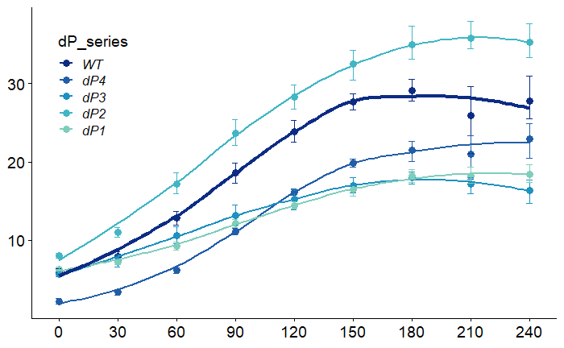

```r
#ggsave("output/OL_0Pi_norescue.png", width = 6, height = 8)


# Generate a darker subset of colors
n_colors <- 7  # Generate more colors than needed
full_palette <- brewer.pal(n_colors, "YlGnBu") # display.brewer.all()
darker_palette <- full_palette[7:3]  # Select a subset of darker colors

# Create a scale for the darker colors
scale_darker_ygb <- scale_color_manual(values = darker_palette)

pi.ol.dat %>%
  filter(!is.na(new_median), genotype != "rescue") %>%
  ggplot(aes(x = new_time, y = new_median, color = dP_series)) + p.timecourse +
  scale_darker_ygb +
  labs(x = "Phosphate starvation, Time (min)")+
   theme(
    axis.title.x = element_blank(),
    axis.title.y = element_blank()
  )
ggsave("output/OL_0Pi_ygb.png", width = 3.7, height = 6)
```

```r
NA
NA
```

#### 2mM H2O2 Data

Import 2mM H2O2 OL data and get the replicate, time and genotype info

```r
files <- dir("input/OL_2mMH2O2", pattern = "d*") # get the file names of the merged
files <- file.path("input//OL_2mMH2O2", files)      # this appends the directory to the file names
names(files) <- c("Rep1-2mMH2O2","Rep2-2mMH2O2", "Rep3-2mMH2O2", "Rep4-2mMH2O2")

tp <- c("0min",  "30min", "60min", "90min", "120min", "150min",  "180min", "210min", "240min") # ordered time points

# import and process the data to the format we want
data.ol.oxi <- map_dfr(files, ~read_csv(., na = c("", "NA", "N/A"), col_types = cols()), .id = "Replicate") %>%
  #bind_rows(.id = "Replicate") %>%
  filter(`X Parameter` == "BL1-H", is.na(`Y Parameter`)) %>%
  select(Replicate, Group, Sample, Count, median = `X Median`, peak = `X Peak`,
         sd = `X SD`, cv = `X %CV`, rCV = `X %rCV`) %>%
  separate(Group, into = c('Time', 'Treatment'), sep = "-") %>%
  mutate(Time = ordered(Time, levels = tp)) %>%
  mutate(Sample = case_when(Sample == "CTA1-GFP-yH298" ~ "yH298-wt",
            Sample == "CTA1-GFP-yH299" ~ "yH299-wt",
            Sample == "yH343-wt" ~ "yH343-rescue",
            Sample == "yH344-wt" ~ "yH344-rescue",
            TRUE ~ Sample)) %>%
  mutate(Replicate = gsub("\\-.*","", Replicate)) %>% #
  separate(Sample, into = c("Strain", "genotype"), sep = "-") %>%
  arrange(Time)
# To replace the value: ifelse() for a single test, case_when() for multiple test
# \\-: escape character "\\" used to escape the special meaning of -, instead take - as a common regex pattern. Or we can specify the - as a regex pattern within a square bracket class [-]
#.*: This part matches any sequence of characters (.* is a common regex pattern for "any character, zero or more times"). metacharacter
```

#### under 2mM H2O2

Plot the internal removal variants data(OL)

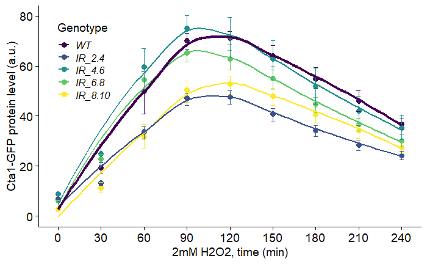

```r
oxi.ol.dat <- data.ol.oxi %>%
  filter(genotype %in% c("wt", "4OL", "6OL", "8OL", "10OL","rescue")) %>%
  select(Time, replicate = Replicate, genotype, median, Strain) %>%
  mutate(Genotype = fct_recode(genotype, !!!levels)) %>%
  mutate(new_median =median/1000) %>%
  mutate(new_time = as.numeric(gsub("min","",Time)))%>%
  arrange(new_time, genotype, replicate)%>%
  mutate(genotype = factor(genotype, levels = levels))%>%
  mutate(Genotype = factor(Genotype, levels = G.levels)) %>%
  mutate(dP_series = fct_recode(genotype, 'WT' = "wt", 'PC' = "rescue", 'dP4' = "10OL", 'dP3' = "8OL", 'dP2' = "6OL", 'dP1' = "4OL"))


oxi.ol.dat %>%
  filter(!is.na(new_median), genotype != "rescue") %>%
  ggplot(aes(x = new_time, y = new_median, color = Genotype)) + p.timecourse +
  scale_color_viridis_d(limits = names(levels.norescue)) +
  xlab("2mM H2O2, time (min)")
```

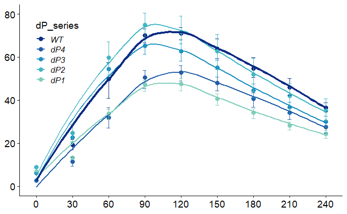

```r
#ggsave("output/OL_oxi.png", width = 6, height = 8)


# Generate a darker subset of colors
n_colors <- 7  # Generate more colors than needed
full_palette <- brewer.pal(n_colors, "YlGnBu") # display.brewer.all()
darker_palette <- full_palette[7:3]  # Select a subset of darker colors

# Create a scale for the darker colors
scale_darker_ygb <- scale_color_manual(values = darker_palette)

oxi.ol.dat %>%
  filter(!is.na(new_median), genotype != "rescue") %>%
  ggplot(aes(x = new_time, y = new_median, color = dP_series)) + p.timecourse +
  scale_darker_ygb +
  labs(x = "Phosphate starvation, Time (min)")+
   theme(
    axis.title.x = element_blank(),
    axis.title.y = element_blank()
  )
ggsave("output/OL_oxi_ygb.png", width = 3.7, height = 6)
```

## Basal expression level of OL variants

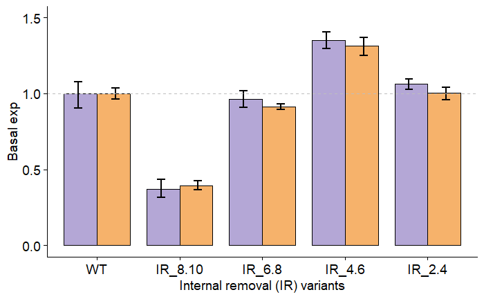

```r
ir.bas.rel %>%
  filter(!is.na(rel_base), Time == "0min") %>%
  ggplot(aes(x = Genotype, y = rel_base, fill = Treatment, pattern = Treatment)) + bar.list.no.stat +
  geom_bar_pattern(stat = "summary", fun = "mean",
                   position = position_dodge(preserve = "single"),
                   color = "black",
                   pattern_fill = "black",
                   pattern_angle = 45,
                   pattern_density = 0.1,  # 0.1
                   pattern_spacing = 0.04,  # 0.025
                   pattern_key_scale_factor = 1,
                   width=0.8) +
  scale_fill_manual(values = c("#b4a7d6ff","#f6b26bff")) +
  scale_pattern_manual(values = c(`0Pi` = "stripe", `2mMH2O2` = "none")) +
  geom_errorbar(stat = "summary", fun.data = mean_cl_boot, width = 0.2, color = "Black", linewidth = 1, position =
                  position_dodge(width = .9)) +
  scale_y_continuous(limits = c(0, 1.5)) +
  #geom_jitter(width = 0.3) +
  geom_hline(yintercept = 1, col = "gray", linetype = "dashed") +
  xlab("Internal removal (IR) variants") +
  ylab("Basal exp") +
  guides(fill = guide_legend(nrow = 1)) +
  theme(strip.background = element_rect(colour="black", fill="white", size=1, linetype="solid"), legend.position = "none")
ggsave("output/Ir_basal_rel_bar.png", width = 10.16, height = 2)
```

## Plateau/maximum expression Level of OL variants (V1)

The logic is cancel out the impact of basal expression level of each variants. To do so, minus the 0 min basal expression level from each variants, then plot the deduced data at all tp and the selected tp.

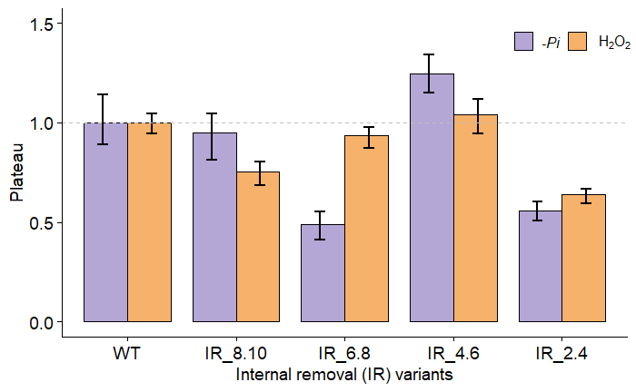

## Induction Rate of OL variants (V2)

The logic is get the median value of each variants at 0 minutes, then calculate the relative induction rate = Vartp/Var0min

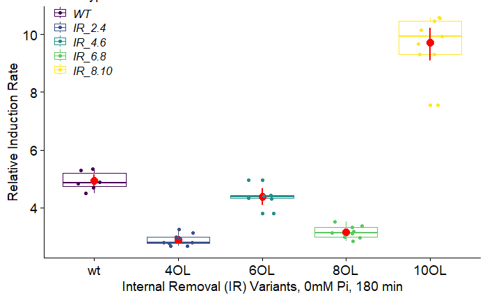

```r
# calculate basal mean
data.basal_mean.pi <- data.ol %>% filter(!is.na(new_median), Time == "0min", Treatment == "0Pi") %>% group_by(Genotype) %>% mutate(basal_mean = mean(new_median)) %>% select(basal_mean, genotype)
data.basal_mean.h2o2 <- data.ol %>% filter(!is.na(new_median), Time == "0min", Treatment == "2mM") %>% group_by(Genotype) %>% mutate(basal_mean = mean(new_median)) %>% select(basal_mean, genotype)
# calculate the relative induction rate
ind.ol.pi <- left_join(pi.ol.dat, data.basal_mean.pi, by = "genotype") %>% unique() %>%
  mutate(ind_rate = new_median/basal_mean) %>% select(-c("Genotype.y")) %>% mutate(genotype = factor(genotype, levels = levels))
colnames(ind.ol.pi)[colnames(ind.ol.pi) == 'Genotype.x'] <- 'Genotype'

ind.ol.h2o2 <- left_join(oxi.ol.dat, data.basal_mean.h2o2, by = "genotype") %>% unique() %>%
  mutate(ind_rate = new_median/basal_mean) %>% select(-c("Genotype.y")) %>% mutate(genotype = factor(genotype, levels = levels))
colnames(ind.ol.h2o2)[colnames(ind.ol.h2o2) == 'Genotype.x'] <- 'Genotype'

# - Pi: at 180min
ind.ol.pi %>%
  filter(!is.na(new_median), genotype != "rescue", Time == "180min") %>%
  ggplot(aes(x = genotype, y = ind_rate, color = Genotype)) + bar.list +
  geom_boxplot() +
  stat_summary(fun.data = "mean_cl_boot", color = "Red", linewidth = 1, size = 0.8) +
  geom_jitter(width = 0.2) +
  scale_color_viridis_d(limits = names(levels.norescue)) +
  ylab("Relative Induction Rate") +
  xlab("Internal Removal (IR) Variants, 0mM Pi, 180 min")
```

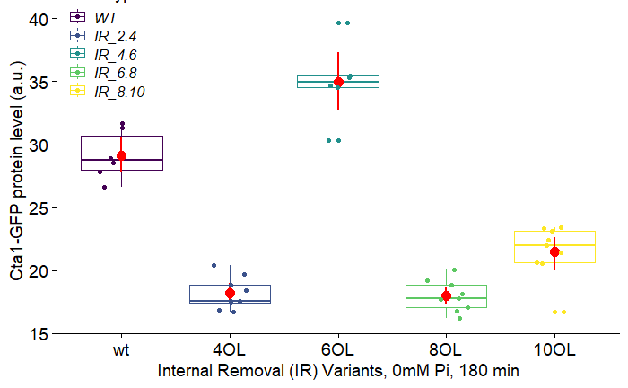

```r
#ggsave("output/OL_ind_0Pi_180.png", width = 6, height = 8)

# calculate the raw max CTA1-GFp
ind.ol.pi %>%
  filter(!is.na(new_median), genotype != "rescue", Time == "180min") %>%
  ggplot(aes(x = genotype, y = new_median, color = Genotype)) + bar.list +
  geom_boxplot() +
  stat_summary(fun.data = "mean_cl_boot", color = "Red", linewidth = 1, size = 0.8) +
  geom_jitter(width = 0.2) +
  scale_color_viridis_d(limits = names(levels.norescue)) +
  xlab("Internal Removal (IR) Variants, 0mM Pi, 180 min")
```

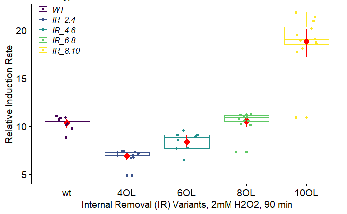

```r
#ggsave("output/OL_raw_0Pi_180.png", width = 6, height = 8)


# 2mM H2O2: at 90min
ind.ol.h2o2 %>%
  filter(!is.na(new_median), genotype != "rescue", Time == "90min") %>%
  ggplot(aes(x = genotype, y = ind_rate, color = Genotype)) + bar.list +
  geom_boxplot() +
  stat_summary(fun.data = "mean_cl_boot", color = "Red", linewidth = 1, size = 0.8) +
  geom_jitter(width = 0.2) +
  scale_color_viridis_d(limits = names(levels.norescue)) +
  ylab("Relative Induction Rate") +
  xlab("Internal Removal (IR) Variants, 2mM H2O2, 90 min")
```

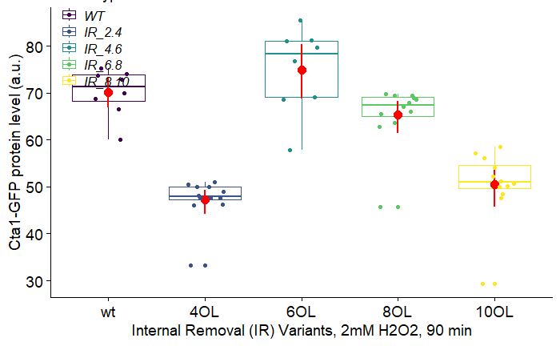

```r
#ggsave("output/OL_ind_H2O2_90.png", width = 6, height = 8)

# calculate the raw max CTA1-GFp
ind.ol.h2o2 %>%
  filter(!is.na(new_median), genotype != "rescue", Time == "90min") %>%
  ggplot(aes(x = genotype, y = new_median, color = Genotype)) + bar.list +
  geom_boxplot() +
  stat_summary(fun.data = "mean_cl_boot", color = "Red", linewidth = 1, size = 0.8) +
  geom_jitter(width = 0.2) +
  scale_color_viridis_d(limits = names(levels.norescue)) +
  xlab("Internal Removal (IR) Variants, 2mM H2O2, 90 min")
```

```r
#ggsave("output/OL_raw_H2O2_90.png", width = 6, height = 8)
```

##### 2mM H2O2 OL timepoint plot function

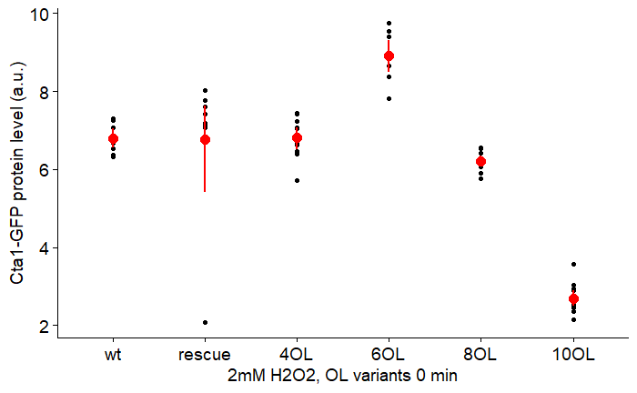

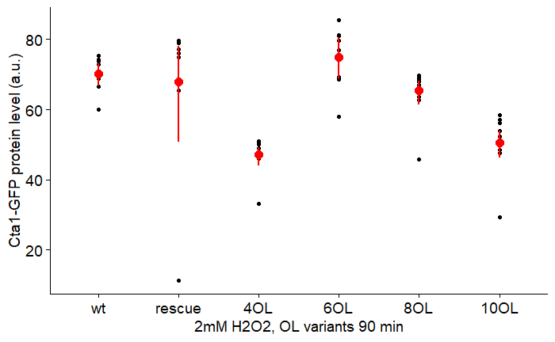

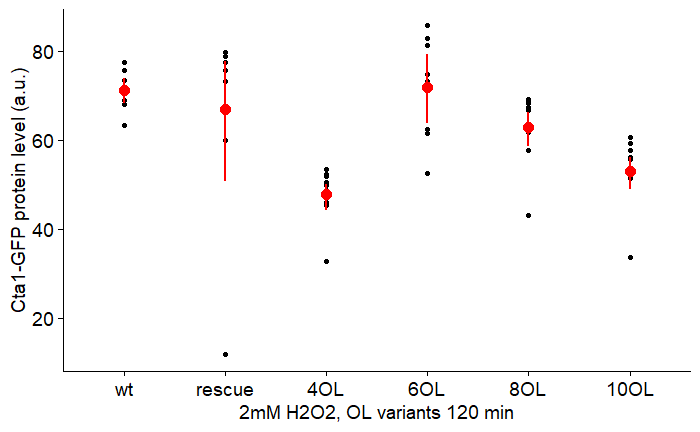

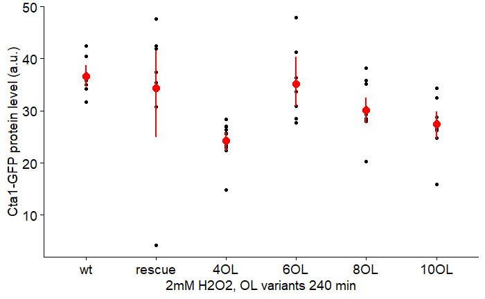

```r
tp_GFP <- function(...){

  all_tp <- list(...)
  for (input_tp in all_tp) {

    df_tp <- oxi.ol.dat %>% filter(new_time == input_tp) %>% mutate(genotype = factor(genotype, levels = levels))

    print(ggplot(df_tp, aes(x = genotype, y = new_median, fill = Genotype)) +
    geom_point() +
    stat_summary(fun.data = "mean_cl_boot", conf.int = .95, color = "Red", linewidth = 1, size = 0.8) +
    labs(x =paste0("2mM H2O2, OL variants ", deparse1(substitute(input_tp)), " min"), y = "Cta1-GFP protein level (a.u.)") +
    theme_cowplot(line_size = 0.7, font_size = 14) +
    theme(legend.position = "none",
          axis.title = element_text(size = rel(1)),
          axis.text.x = element_text(hjust=0.5), axis.text = element_text(size = rel(1)),))
  }
}

# plot the 2mM H2O2 OL variants at 0min, 90min, 120min timepoints

tp_GFP(0,90,120,240)
```

```r
NA
NA
```

**Overlapping variants** ### slope/differetiation of the loess curve

```r
# plot & calculate the slope/differiation changes of OL:- Pi
# check the non-duplicated strain names
check <- pi.ol.dat %>%  group_by(Genotype) %>% summarise(Strain = paste(unique(Strain), collapse = ', '))

# Can play the the genotype name to plot the diff(loess model)
test.pi <- pi.ol.dat %>% filter(Genotype == "IR_2.4") %>% loess(formula = new_median ~ new_time, span = 0.75, degree = 2)

x <- 0:240
px <- predict(test.pi, newdata = x)
px1 <- diff(px)
which.max(px1) # get the x value
```

```
[1] 79
```

```r
max(px1) # equals px1[which.max(px1)]
```

```
[1] 0.08934053
```

```r
par(mfrow=c(1, 2))
plot(x, px, main="loess model")

plot(x[-1], px1, main="diff(loess model)")
```

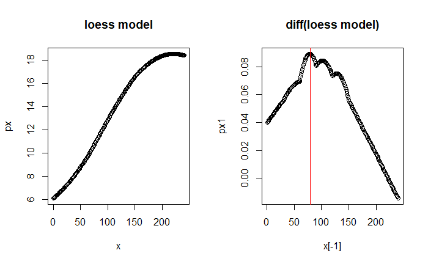

```r
abline(v=which.max(px1), col="red")
```

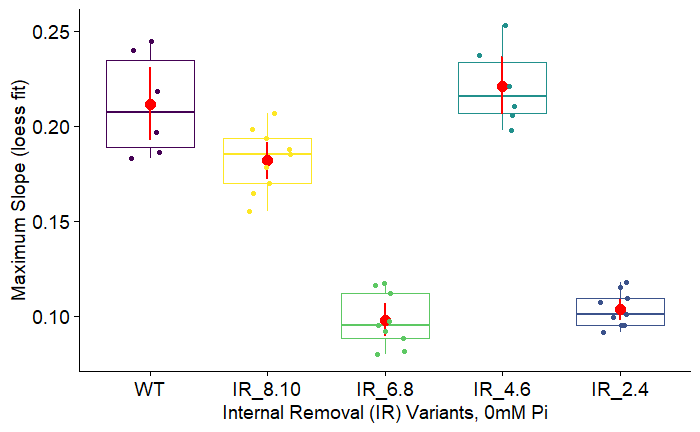

```r
# get the max slope and the respective tp for each sample into a dataframe: - Pi
pi.slope <- data.frame(matrix(ncol=2,nrow=0, dimnames=list(NULL, c("slope", "Genotype"))))
row_cnt = 1
col_cnt = 1
for (x in names(levels)) {
  tmp.pi <- pi.ol.dat %>% filter(Genotype == x)
# get the loess function
  for (y in unique(pi.ol.dat$replicate)) {
    test.pi <- tmp.pi %>% filter(replicate == y)
    for (z in unique(test.pi$Strain)) {
      final.pi <- test.pi %>% filter(Strain == z) %>% loess(formula = new_median ~ new_time, span = 0.75, degree = 2)
      x_var <- 0:240
      px <- predict(final.pi, newdata = x_var)
      # perform differentiation
      tmp <- max(diff(px))
      gt_tmp <- x
      pi.slope[row_cnt,col_cnt] <- tmp
      col_cnt = col_cnt + 1
      pi.slope[row_cnt,col_cnt] <- gt_tmp
      col_cnt = 1
      row_cnt = row_cnt + 1
    }}}


pi.slope <- pi.slope %>%
  mutate(Genotype = factor(Genotype, levels = G.levels)) %>%
  mutate(Treatment = "0Pi")

# plot the slope of the curve: - Pi
pi.slope %>%
  filter(!is.na(slope), Genotype != "PC") %>%
  ggplot(aes(x = Genotype, y = slope, color = Genotype)) + bar.list +
  geom_boxplot() +
  stat_summary(fun.data = "mean_cl_boot", color = "Red", linewidth = 1, size = 0.8) +
  geom_jitter(width = 0.2) +
  theme(legend.position = "none") +
  scale_color_viridis_d(limits = names(levels.norescue)) +
  ylab("Maximum Slope (loess fit)") +
  xlab("Internal Removal (IR) Variants, 0mM Pi")
```

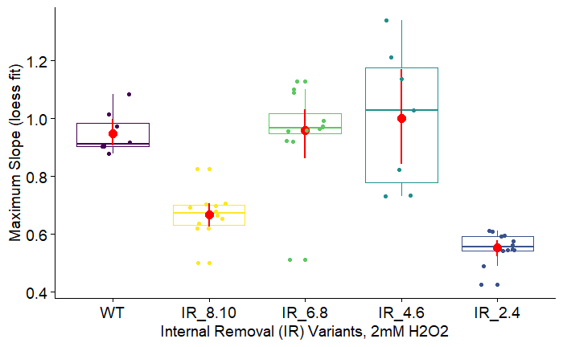

```r
#ggsave("output/OL_slope_0Pi.png", width = 6, height = 8)


# get the max slope and the respective tp for each sample into a dataframe: 2mM H2O2
oxi.slope <- data.frame(matrix(ncol=2,nrow=0, dimnames=list(NULL, c("slope", "Genotype"))))
row_cnt = 1
col_cnt = 1
for (x in names(levels)) {
  tmp.oxi <- oxi.ol.dat %>% filter(Genotype == x)
# get the loess function
  for (y in unique(oxi.ol.dat$replicate)) {
    test.oxi <- tmp.oxi %>% filter(replicate == y)
    for (z in unique(test.oxi$Strain)) {
      final.oxi <- test.oxi %>% filter(Strain == z) %>% loess(formula = new_median ~ new_time, span = 0.75, degree = 2)
      x_var <- 0:240
      px <- predict(final.oxi, newdata = x_var)
      # perform differentiation
      tmp <- max(diff(px))
      gt_tmp <- x
      oxi.slope[row_cnt,col_cnt] <- tmp
      col_cnt = col_cnt + 1
      oxi.slope[row_cnt,col_cnt] <- gt_tmp
      col_cnt = 1
      row_cnt = row_cnt + 1
    }}}


oxi.slope <- oxi.slope %>%
  mutate(Genotype = factor(Genotype, levels =G.levels)) %>%
  mutate(Treatment = "2mMH2O2")

# plot the slope of the curve: - Pi
oxi.slope %>%
  filter(!is.na(slope), Genotype != "PC") %>%
  ggplot(aes(x = Genotype, y = slope, color = Genotype)) + bar.list +
  geom_boxplot() +
  stat_summary(fun.data = "mean_cl_boot", color = "Red", linewidth = 1, size = 0.8) +
  geom_jitter(width = 0.2) +
  theme(legend.position= "None") +
  scale_color_viridis_d(limits = names(levels.norescue)) +
  ylab("Maximum Slope (loess fit)") +
  xlab("Internal Removal (IR) Variants, 2mM H2O2")
```

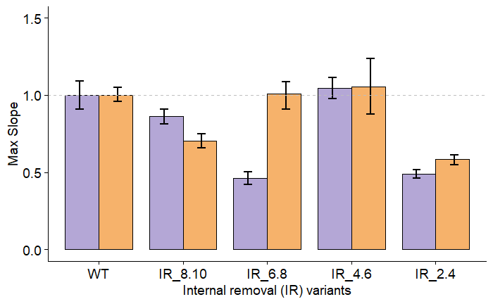

```r
#ggsave("output/OL_slope_oxi.png", width = 6, height = 8)


# get the maximum slope relative to the wt
pi.slope.rel <- pi.slope %>% filter(!is.na(slope)) %>%
  group_by(Genotype) %>%
  mutate(mean_slope = mean(slope)) %>%
  mutate(wt_slope = mean(.[.$Genotype == "WT",]$mean_slope)) %>%
  mutate(rel_slope = slope/wt_slope)

oxi.slope.rel <- oxi.slope %>% filter(!is.na(slope)) %>%
  group_by(Genotype) %>%
  mutate(mean_slope = mean(slope)) %>%
  mutate(wt_slope = mean(.[.$Genotype == "WT",]$mean_slope)) %>%
  mutate(rel_slope = slope/wt_slope)

# get the combined slope
ol.slope <- bind_rows(pi.slope.rel, oxi.slope.rel)

# plot the maximum slope relative to wt
ol.slope %>%
  filter(!is.na(rel_slope), Genotype != "PC") %>%
  ggplot(aes(x = Genotype, y = rel_slope, fill = Treatment, pattern = Treatment)) + bar.list.no.stat +
 geom_bar_pattern(stat = "summary", fun = "mean",
                   position = position_dodge(preserve = "single"),
                   color = "black",
                   pattern_fill = "black",
                   pattern_angle = 45,
                   pattern_density = 0.1,  # 0.1
                   pattern_spacing = 0.04,  # 0.025
                   pattern_key_scale_factor = 1,
                   width=0.8) +
  scale_fill_manual(values = c("#b4a7d6ff","#f6b26bff")) +
  scale_pattern_manual(values = c(`0Pi` = "stripe", `2mMH2O2` = "none")) +
  geom_errorbar(stat = "summary", fun.data = mean_cl_boot, width = 0.2, color = "Black", linewidth = 1, position =
                  position_dodge(width = .9)) +
  scale_y_continuous(limits = c(0, 1.5)) +
  #geom_jitter(width = 0.3) +
  geom_hline(yintercept = 1, col = "gray", linetype = "dashed") +
  xlab("Internal removal (IR) variants") +
  ylab("Max Slope") +
  guides(fill = guide_legend(nrow = 1)) +
  theme(strip.background = element_rect(colour="black", fill="white", size=1, linetype="solid"), legend.position= "none")
ggsave("output/OL_slope_rel_max.png", width = 10.16, height = 2)
```

```r
NA
NA
NA
NA
NA
```

#### Get the loess curve fitting for the timecourse data

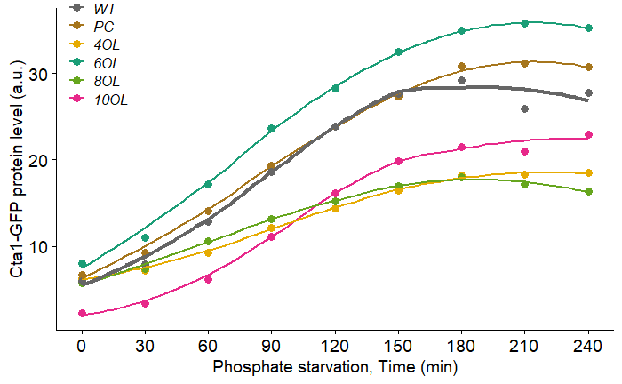

```r
# need names_colors
genotype_color <- RColorBrewer::brewer.pal(8, "Dark2")[c(8, 7, 6, 1, 5, 4)]
names(genotype_color) <- names(levels)

# check for the loss fit curve
pi.ol.dat %>% ggplot(aes(x = new_time, y = new_median, color = Genotype)) + mean.timecourse + scale_color_manual(values= genotype_color, limits = names(genotype_color)) +
  labs(x = "Phosphate starvation, Time (min)")
```

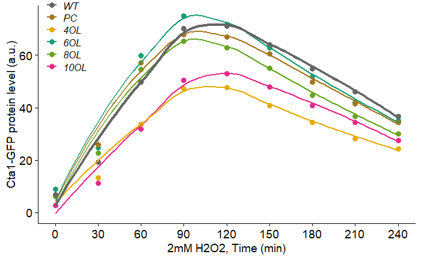

```r
#ggsave("output/loess_Ol_0Pi.png", width = 6.3, height = 8)

oxi.ol.dat %>% ggplot(aes(x = new_time, y = new_median, color = Genotype)) + mean.timecourse + scale_color_manual(values= genotype_color, limits = names(genotype_color)) +
labs(x = "2mM H2O2, Time (min)")
```

```r
#ggsave("output/loess_Ol_2mMH2O2.png", width = 6.3, height = 8)


## get AUC for - Pi data into a dataframe
pi.area <- data.frame(matrix(ncol=2,nrow=0, dimnames=list(NULL, c("pi.area", "Genotype"))))
row_cnt = 1
col_cnt = 1
for (x in names(genotype_color)) {
# calculate AUC
madeup.pi <- pi.ol.dat %>% filter(Genotype == x) %>% loess(formula = new_median ~ new_time, span = 0.75, degree = 2)
f <- function(x) predict(madeup.pi,newdata=x)
# perform integration
tmp <- integrate(f,0,240)$value
gt_tmp <- x
pi.area[row_cnt,col_cnt] <- tmp
col_cnt = col_cnt + 1
pi.area[row_cnt,col_cnt] <- gt_tmp
col_cnt = 1
row_cnt = row_cnt + 1
}


# get AUC for 2mM H2O2 data
h2o2.area <- data.frame(matrix(ncol=2,nrow=0, dimnames=list(NULL, c("h2o2.area", "Genotype"))))
row_cnt = 1
col_cnt = 1
for (x in names(genotype_color)) {
# calculate AUC
madeup.h2o2 <- oxi.ol.dat %>% filter(Genotype == x) %>% loess(formula = new_median ~ new_time, span = 0.75, degree = 2)
f <- function(x) predict(madeup.h2o2,newdata=x)
# perform integration
tmp <- integrate(f,0,240)$value
gt_tmp <- x
h2o2.area[row_cnt,col_cnt] <- tmp
col_cnt = col_cnt + 1
h2o2.area[row_cnt,col_cnt] <- gt_tmp
col_cnt = 1
row_cnt = row_cnt + 1
}

# combind area data
area.ol <- merge(pi.area,h2o2.area)
```

#### Check the loess fitting assumption: normality and curve fitting

### regulatory information map

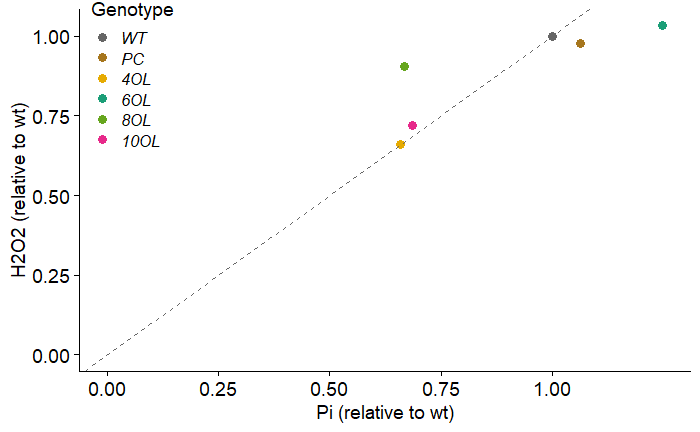

```r
# calculate the relative information retaining within each genotype
reg_info.ol <- area.ol %>%
  mutate(pi_pcnt = pi.area/(.[.$Genotype == "WT",]$pi.area)) %>%
  mutate(h2o2_pcnt = h2o2.area/((.[.$Genotype == "WT",]$h2o2.area)))

reg_info.ol %>%
  ggplot(aes(x = pi_pcnt, y = h2o2_pcnt), color = Genotype) +
  scatter +
  geom_point(size = 3, aes(color = Genotype)) +
  geom_abline(slope = 1, intercept = 0, linetype = "dashed", color = "#666666") +
  labs(x = "Pi (relative to wt)", y = "H2O2 (relative to wt)") +
  scale_color_manual(values = genotype_color, limits = names(genotype_color))
```

```r
#ggsave("output/Olvswt_0pivsh2o2_scatter.png", width = 6.3, height = 6.3)

# save the reg_info.ol
#write.csv(reg_info.ol, file = "output/ol_pct.csv", row.names = F)
#write.csv(reg_info.ol, file = "../RS_TrunV/input/ol_pct.csv", row.names = F)
```

### Import TrunV data and get the replicate, time and genotype info

```r
files <- dir("input/TrunV_0Pi", pattern = "d01*") # get the file names of the merged
files <- file.path("input//TrunV_0Pi", files)         # this appends the directory to the file names
names(files) <- c("Rep1-0Pi-Ctrl","Rep2-0Pi-Ctrl", "Rep3-0Pi-Ctrl")

tp <- c("0min",  "30min", "60min", "90min", "120min", "150min",  "180min", "210min", "240min") # ordered time points

# import and process the data to the format we want
data.TrunV.pi <- map_dfr(files, ~read_csv(., na = c("", "NA", "N/A"), col_types = cols()), .id = "Replicate") %>%
  #bind_rows(.id = "Replicate") %>%
  filter(!is.na(median),`X Parameter` == "BL1-H", is.na(`Y Parameter`)) %>%
  select(Replicate, Group, Sample, Count, median = `X Median`, peak = `X Peak`,
         sd = `X SD`, cv = `X %CV`, rCV = `X %rCV`) %>%
  separate(Group, into = c('Time', 'Treatment'), sep = "-") %>%
  mutate(Time = ordered(Time, levels = tp)) %>%
  mutate(Sample = case_when(Sample == "CTA1-GFP-yH298" ~ "yH298-wt",
            Sample == "CTA1-GFP-yH299" ~ "yH299-wt",
            Sample == "yH343-wt" ~ "yH343-rescue",
            Sample == "yH344-wt" ~ "yH344-rescue",
            TRUE ~ Sample)) %>%
  mutate(Replicate = gsub("\\-.*","", Replicate)) %>%
  separate(Sample, into = c("Strain", "genotype"), sep = "-") %>%
  filter(!is.na(median)) %>%
  arrange(Time)
# To replace the value: ifelse() for a single test, case_when() for multiple test
# \\-: escape character "\\" used to escape the special meaning of -, instead take - as a common regex pattern. Or we can specify the - as a regex pattern within a square bracket class [-]
#.*: This part matches any sequence of characters (.* is a common regex pattern for "any character, zero or more times"). metacharacter
```

#### Plot the truncation variants data (TrunV)

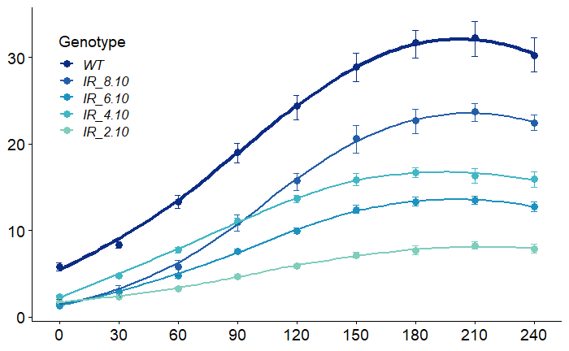

```r
# recode the genotype
levels <- c(`WT` = "wt", `PC`= "rescue", `IR_8.10` = "8V", `IR_6.10` = "6V", `IR_4.10` = "4V", `IR_2.10` = "2V" )
levels.norescue <- c(`WT` = "wt",`IR_8.10` = "8V", `IR_6.10` = "6V", `IR_4.10` = "4V", `IR_2.10` = "2V" )
G.levels <- c("WT", "PC", "IR_8.10", "IR_6.10", "IR_4.10", "IR_2.10")


pi.TrunV.dat <- data.TrunV.pi %>%
  filter(genotype %in% c("wt", "2V", "4V", "6V", "8V","rescue")) %>%
  select(Time, replicate = Replicate, genotype, Strain, median) %>%
  mutate(Genotype = fct_recode(genotype, !!!levels)) %>%
  mutate(new_median =median/1000) %>%
  mutate(new_time = as.numeric(gsub("min","",Time)))%>%
  arrange(new_time, genotype, replicate) %>%
  mutate(Genotype = factor(Genotype, levels = G.levels))

# Generate a darker subset of colors
n_colors <- 7  # Generate more colors than needed
full_palette <- brewer.pal(n_colors, "YlGnBu")
darker_palette <- full_palette[7:3]  # Select a subset of darker colors

# Create a scale for the darker colors
scale_darker_ygb <- scale_color_manual(values = darker_palette)


pi.TrunV.dat %>%
  filter(!is.na(new_median), genotype != "rescue") %>%
  ggplot(aes(x = new_time, y = new_median, color = Genotype)) + p.timecourse +
  scale_darker_ygb +
  labs(x = "Phosphate starvation, Time (min)")+
   theme(
    axis.title.x = element_blank(),
    axis.title.y = element_blank()
  )
ggsave("output/TrunV_0Pi_ygb.png", width = 3.7, height = 6)
```

#### 2mM H2O2 Data

Import 2mM H2O2 TrunV data and get the replicate, time and genotype info

```r
files <- dir("input/TrunV_2mMH2O2", pattern = "d*") # get the file names of the merged
files <- file.path("input//TrunV_2mMH2O2", files)      # this appends the directory to the file names
names(files) <- c("Rep1-2mMH2O2","Rep2-2mMH2O2", "Rep3-2mMH2O2")

tp <- c("0min",  "30min", "60min", "90min", "120min", "150min",  "180min", "210min", "240min") # ordered time points

# import and process the data to the format we want
data.TrunV.oxi <- map_dfr(files, ~read_csv(., na = c("", "NA", "N/A"), col_types = cols()), .id = "Replicate") %>%
  #bind_rows(.id = "Replicate") %>%
  filter(`X Parameter` == "BL1-H", is.na(`Y Parameter`)) %>%
  select(Replicate, Group, Sample, Count, median = `X Median`, peak = `X Peak`,
         sd = `X SD`, cv = `X %CV`, rCV = `X %rCV`) %>%
  separate(Group, into = c('Time', 'Treatment'), sep = "-") %>%
  mutate(Time = ordered(Time, levels = tp)) %>%
  mutate(Sample = case_when(Sample == "CTA1-GFP-yH298" ~ "yH298-wt",
            Sample == "CTA1-GFP-yH299" ~ "yH299-wt",
            Sample == "yH343-wt" ~ "yH343-rescue",
            Sample == "yH344-wt" ~ "yH344-rescue",
            TRUE ~ Sample)) %>%
  mutate(Replicate = gsub("\\-.*","", Replicate)) %>% #
  separate(Sample, into = c("Strain", "genotype"), sep = "-") %>%
  filter(!is.na(median)) %>%
  arrange(Time)
# To replace the value: ifelse() for a single test, case_when() for multiple test
# \\-: escape character "\\" used to escape the special meaning of -, instead take - as a common regex pattern. Or we can specify the - as a regex pattern within a square bracket class [-]
#.*: This part matches any sequence of characters (.* is a common regex pattern for "any character, zero or more times"). metacharacter
```

#### under 2mM H2O2

Plot the Truncation variants data(TrunV)

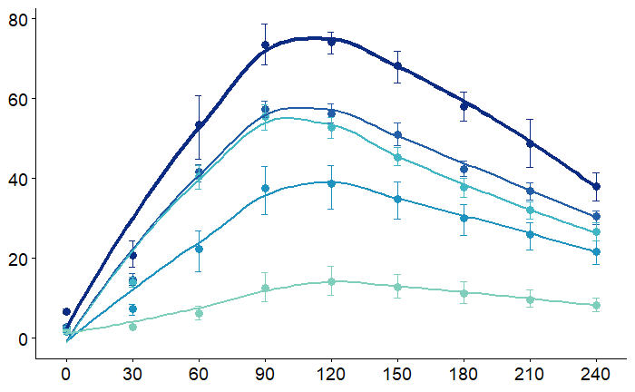

```r
# use the recoded the genotype

oxi.TrunV.dat <- data.TrunV.oxi  %>%
  filter(genotype %in% c("wt", "2V", "4V", "6V", "8V","rescue")) %>%
  select(Time, replicate = Replicate, genotype, Strain, median) %>%
  mutate(Genotype = fct_recode(genotype, !!!levels)) %>%
  mutate(new_median =median/1000) %>%
  mutate(new_time = as.numeric(gsub("min","",Time)))%>%
  arrange(new_time, genotype, replicate) %>%
  mutate(Genotype = factor(Genotype, levels = G.levels))


# Generate a darker subset of colors
n_colors <- 7  # Generate more colors than needed
full_palette <- brewer.pal(n_colors, "YlGnBu")
darker_palette <- full_palette[7:3]  # Select a subset of darker colors

# Create a scale for the darker colors
scale_darker_ygb <- scale_color_manual(values = darker_palette)



oxi.TrunV.dat %>%
  filter(!is.na(new_median), genotype != "rescue") %>%
  ggplot(aes(x = new_time, y = new_median, color = Genotype)) + p.timecourse +
  scale_darker_ygb +
  xlab("2mM H2O2 stress, time (min)") +
  theme(
    axis.title.x = element_blank(),
    axis.title.y = element_blank(),
    legend.position = "none"
  )
ggsave("output/TrunV_oxi_ygb.png", width = 3.7, height = 6)
```

## Basal expression level of Truncation variants

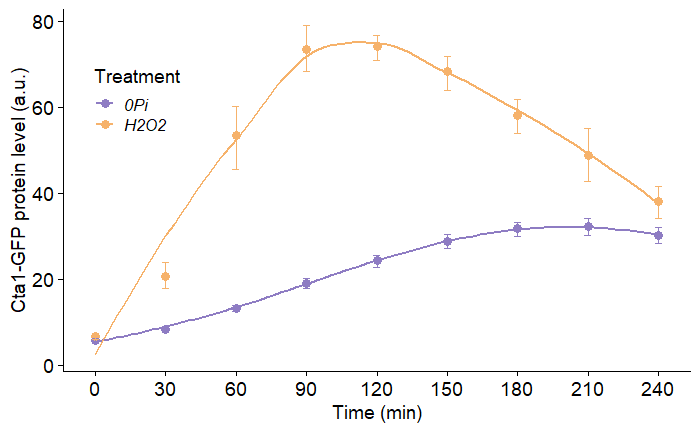

```r
# Use 0min data from both H2O2 and -Pi treatment;
data.TrunV <- bind_rows(data.TrunV.oxi,data.TrunV.pi) %>%
  select(Time, replicate = Replicate, genotype, median, Treatment) %>%
  mutate(Genotype = fct_recode(genotype, !!!levels)) %>%
  mutate(new_median =median/1000) %>%
  mutate(new_time = as.numeric(gsub("min","",Time)))%>%
  arrange(new_time, genotype, replicate) %>%
  mutate(genotype = factor(genotype, levels = levels)) %>%
  mutate(Genotype = factor(Genotype, levels = G.levels))

# plot WT curve at - Pi and 2mM H2O2 conditions
data.TrunV %>%
  filter(!is.na(new_median), Genotype == "WT") %>%
  ggplot(aes(x = new_time, y = new_median, color = Treatment)) + p.timecourse +
  scale_color_manual(values = c("#8e7cc3ff","#f6b26bff"))  +
  xlab("Time (min)")
```

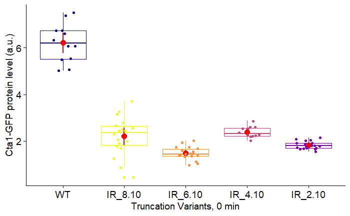

```r
#ggsave("output/TrunV_oxi_norescue.png", width = 6, height = 8)


data.TrunV %>%
  filter(!is.na(new_median), genotype != "rescue", Time == "0min") %>%
  ggplot(aes(x = Genotype, y = new_median, color = Genotype)) + bar.list +
  geom_boxplot() +
  stat_summary(fun.data = "mean_cl_boot", color = "Red", linewidth = 1, size = 0.8) +
  geom_jitter(width = 0.2) +
  scale_color_viridis_d(limits = names(levels.norescue), option = "plasma") +
  theme(legend.position="none") +
  xlab("Truncation Variants, 0 min")
```

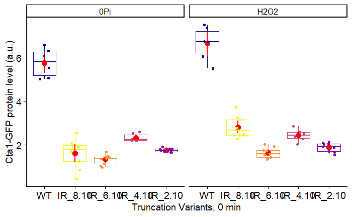

```r
#ggsave("output/TrunV_basal.png", width = 6, height = 8)

## seperately plot the basal level for 0mM Pi and 2mM H2O2
data.TrunV %>%
  filter(!is.na(new_median), genotype != "rescue", Time == "0min") %>%
  ggplot(aes(x = Genotype, y = new_median, color = Genotype)) + bar.list +
  geom_boxplot() +
  stat_summary(fun.data = "mean_cl_boot", color = "Red", linewidth = 1, size = 0.8) +
  geom_jitter(width = 0.2) +
  scale_color_viridis_d(limits = names(levels.norescue), option = "plasma") +
  theme(legend.position=c(0.85,0.9)) +
  xlab("Truncation Variants, 0 min") +
  facet_grid(. ~ Treatment) +
  theme(strip.background = element_rect(colour="black", fill="white", size=1, linetype="solid"), legend.position = "none")
```

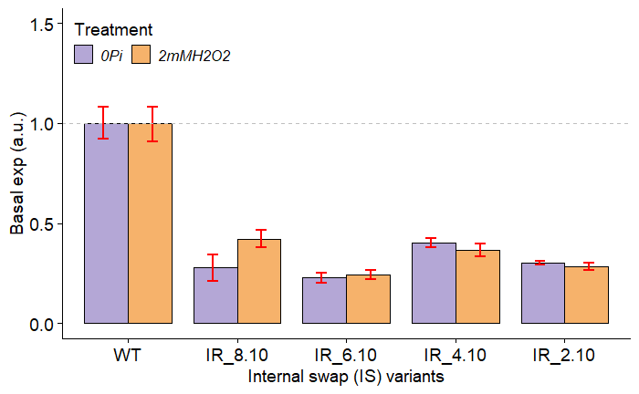

```r
#ggsave("output/TrunV_seperate_basal.png", width = 6, height = 8)


# calculate relative basal expression changes to wt
TrunV.bas.rel.pi <- data.TrunV %>%
          filter(!is.na(new_median), genotype != "rescue", Time == "0min", Treatment == "0Pi") %>%
          group_by(genotype) %>%
          mutate(new_mean_base = mean(median)) %>%
          mutate(wt_basal = mean(.[.$Genotype == "WT",]$new_mean_base)) %>%
          mutate(rel_base = median/wt_basal) %>%
          mutate(Treatment = "0Pi")

TrunV.bas.rel.oxi <- data.TrunV %>%
          filter(!is.na(new_median), genotype != "rescue", Time == "0min", Treatment == "H2O2") %>%
          group_by(genotype) %>%
          mutate(new_mean_base = mean(median)) %>%
          mutate(wt_basal = mean(.[.$Genotype == "WT",]$new_mean_base)) %>%
          mutate(rel_base = median/wt_basal) %>%
          mutate(Treatment = "2mMH2O2")

TrunV.bas.rel <- bind_rows(TrunV.bas.rel.oxi, TrunV.bas.rel.pi)
TrunV.bas.rel.save <- TrunV.bas.rel %>% select(Time, genotype, Genotype, rel_base)


TrunV.bas.rel %>%
  filter(!is.na(rel_base), Time == "0min") %>%
  ggplot(aes(x = Genotype, y = rel_base, fill = Treatment, pattern = Treatment)) + bar.list.no.stat +
  geom_bar_pattern(stat = "summary", fun = "mean",
                   position = position_dodge(preserve = "single"),
                   color = "black",
                   pattern_fill = "black",
                   pattern_angle = 45,
                   pattern_density = 0.1,  # 0.1
                   pattern_spacing = 0.04,  # 0.025
                   pattern_key_scale_factor = 1,
                   width=0.8) +
  scale_fill_manual(values = c("#b4a7d6ff","#f6b26bff")) +
  scale_pattern_manual(values = c(`0Pi` = "stripe", `2mMH2O2` = "none")) +
  geom_errorbar(stat = "summary", fun.data = mean_cl_boot, width = 0.2, color = "Red", linewidth = 1, position =
                  position_dodge(width = .9)) +
  scale_y_continuous(limits = c(0, 1.5)) +
  #geom_jitter(width = 0.3) +
  geom_hline(yintercept = 1, col = "gray", linetype = "dashed") +
  xlab("Internal swap (IS) variants") +
  ylab("Basal exp (a.u.)") +
  guides(fill = guide_legend(nrow = 1)) +
  theme(strip.background = element_rect(colour="black", fill="white", size=1, linetype="solid"))
```

```r
#ggsave("output/TrunV_basal_rel_bar.png", width = 10.16, height = 2)
```

## Plateau/maximum expression Level of Truncation variants (V1)

The logic is cancel out the impact of basal expression level of each variants. To do so, minus the 0 min basal expression level from each variants, then plot the deduced data at all tp and the selected tp.

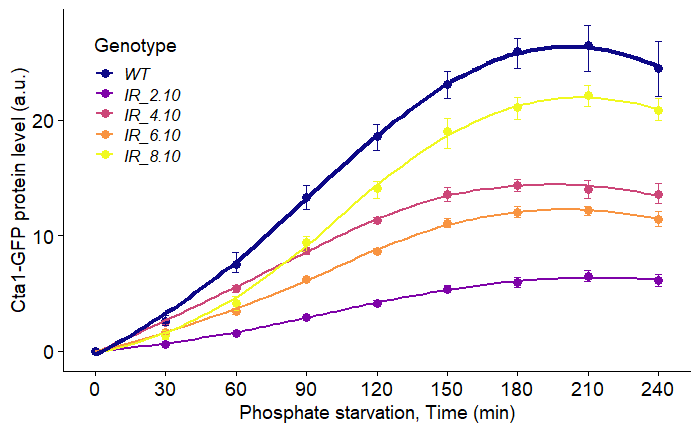

```r
# get the individual basal mean
data.TrunV.pi.basal <- data.TrunV.pi %>% filter(!is.na(median), Time == "0min") %>% group_by(genotype) %>% mutate(basal = median) %>% select(Replicate, Strain, genotype, basal)

data.TrunV.oxi.basal <- data.TrunV.oxi %>% filter(!is.na(median), Time == "0min") %>% group_by(genotype) %>% mutate(basal = median) %>% select(Replicate, Strain, genotype, basal)


pi.TrunV.dect <- merge(data.TrunV.pi, data.TrunV.pi.basal, by = c("Strain", "Replicate","genotype")) %>%
  filter(genotype %in% c("wt", "2V", "4V", "6V", "8V", "rescue")) %>%
  select(Time, replicate = Replicate, genotype, median, basal) %>%
  mutate(Genotype = fct_recode(genotype, !!!levels)) %>%
  mutate(new_median =(median-basal)/1000) %>%
  mutate(new_time = as.numeric(gsub("min","",Time)))%>%
  mutate(genotype = factor(genotype, levels = levels)) %>%
  arrange(new_time, genotype, replicate)

oxi.TrunV.dect <- merge(data.TrunV.oxi, data.TrunV.oxi.basal, by = c("Strain", "Replicate","genotype")) %>%
  filter(genotype %in% c("wt", "2V", "4V", "6V", "8V", "rescue")) %>%
  select(Time, replicate = Replicate, genotype, median, basal) %>%
  mutate(Genotype = fct_recode(genotype, !!!levels)) %>%
  mutate(new_median =(median-basal)/1000) %>%
  mutate(new_time = as.numeric(gsub("min","",Time)))%>%
  mutate(genotype = factor(genotype, levels = levels)) %>%
  arrange(new_time, genotype, replicate)

# timecourse deduct curve
pi.TrunV.dect %>%
  filter(!is.na(new_median), genotype != "rescue") %>%
  ggplot(aes(x = new_time, y = new_median, color = Genotype)) + p.timecourse +
  scale_color_viridis_d(limits = names(levels.norescue), option = "plasma")  +
  labs(x = "Phosphate starvation, Time (min)")
```

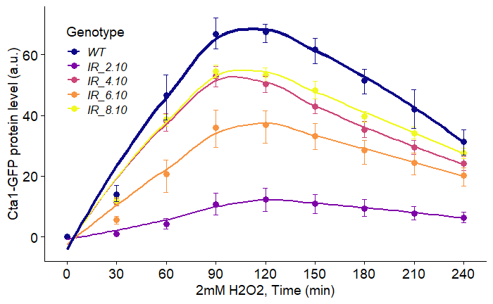

```r
#ggsave("output/TrunV_0Pi_deduct.png", width = 6, height = 8)

oxi.TrunV.dect %>%
  filter(!is.na(new_median), genotype != "rescue") %>%
  ggplot(aes(x = new_time, y = new_median, color = Genotype)) + p.timecourse +
  scale_color_viridis_d(limits = names(levels.norescue), option = "plasma")  +
  labs(x = "2mM H2O2, Time (min)")
```

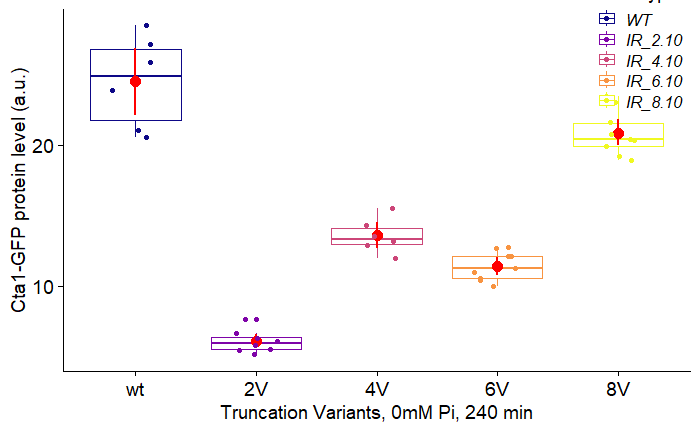

```r
#ggsave("output/TrunV_oxi_deduct.png", width = 6, height = 8)


# single timepoint deduct curve
# - Pi: 240min
pi.TrunV.dect %>%
  filter(!is.na(new_median), genotype != "rescue", Time == "240min") %>%
  ggplot(aes(x = genotype, y = new_median, color = Genotype)) + bar.list +
  geom_boxplot() +
  stat_summary(fun.data = "mean_cl_boot", color = "Red", linewidth = 1, size = 0.8) +
  geom_jitter(width = 0.2) +
  theme(legend.position=c(0.85,0.9)) +
  scale_color_viridis_d(limits = names(levels.norescue), option = "plasma") +
  xlab("Truncation Variants, 0mM Pi, 240 min")
```

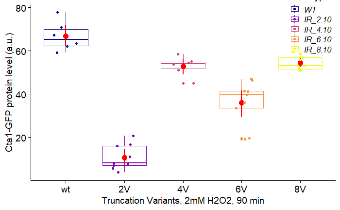

```r
#ggsave("output/TrunV_deduct_0Pi_240.png", width = 6, height = 8)

# 2mM Oxi: 90min
oxi.TrunV.dect %>%
  filter(!is.na(new_median), genotype != "rescue", Time == "90min") %>%
  ggplot(aes(x = genotype, y = new_median, color = Genotype)) + bar.list +
  geom_boxplot() +
  stat_summary(fun.data = "mean_cl_boot", color = "Red", linewidth = 1, size = 0.8) +
  geom_jitter(width = 0.2) +
  theme(legend.position=c(0.85,0.9)) +
  scale_color_viridis_d(limits = names(levels.norescue), option = "plasma") +
  xlab("Truncation Variants, 2mM H2O2, 90 min")
```

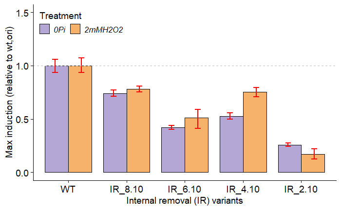

```r
#ggsave("output/TrunV_deduct_Oxi_90.png", width = 6, height = 8)

# calculate maximum plateau relative to wt
pi.TrunV.dect.rel <- pi.TrunV.dect %>% filter(Time == "240min") %>% group_by(genotype) %>%
  mutate(new_mean_ori = mean(median)) %>%
  mutate(new_mean_red = mean(new_median)) %>%
  mutate(wt_ori = mean(.[.$Genotype == "WT",]$new_mean_ori)) %>%
  mutate(wt_red = mean(.[.$Genotype == "WT",]$new_mean_red)) %>%
  mutate(rel_ori = median/wt_ori) %>%
  mutate(rel_red = new_median/wt_red) %>%
  mutate(Treatment = "0Pi")

oxi.TrunV.dect.rel <- oxi.TrunV.dect %>% filter(Time == "90min") %>% group_by(genotype) %>%
  mutate(new_mean_ori = mean(median)) %>%
  mutate(new_mean_red = mean(new_median)) %>%
  mutate(wt_ori = mean(.[.$Genotype == "WT",]$new_mean_ori)) %>%
  mutate(wt_red = mean(.[.$Genotype == "WT",]$new_mean_red)) %>%
  mutate(rel_ori = median/wt_ori) %>%
  mutate(rel_red = new_median/wt_red) %>%
  mutate(Treatment = "2mMH2O2")

TrunV.rel <- bind_rows(pi.TrunV.dect.rel, oxi.TrunV.dect.rel) %>% mutate(Genotype = factor(Genotype, levels = G.levels))

# plot the maximum relative to wt
TrunV.rel %>%
  filter(!is.na(new_median), genotype != "rescue") %>%
  ggplot(aes(x = Genotype, y = rel_ori, fill = Treatment, pattern = Treatment)) + bar.list.no.stat +
  geom_bar_pattern(stat = "summary", fun = "mean",
                   position = position_dodge(preserve = "single"),
                   color = "black",
                   pattern_fill = "black",
                   pattern_angle = 45,
                   pattern_density = 0.1,  # 0.1
                   pattern_spacing = 0.04,  # 0.025
                   pattern_key_scale_factor = 1,
                   width=0.8) +
  scale_fill_manual(values = c("#b4a7d6ff","#f6b26bff")) +
  scale_pattern_manual(values = c(`0Pi` = "stripe", `2mMH2O2` = "none")) +
  geom_errorbar(stat = "summary", fun.data = mean_cl_boot, width = 0.2, color = "Red", linewidth = 1, position =
                  position_dodge(width = .9)) +
  scale_y_continuous(limits = c(0, 1.5)) +
  #geom_jitter(width = 0.3) +
  geom_hline(yintercept = 1, col = "gray", linetype = "dashed") +
  xlab("Internal removal (IR) variants") +
  ylab("Max induction (relative to wt,ori)") +
  guides(fill = guide_legend(nrow = 1)) +
  theme(strip.background = element_rect(colour="black", fill="white", size=1, linetype="solid"))
```

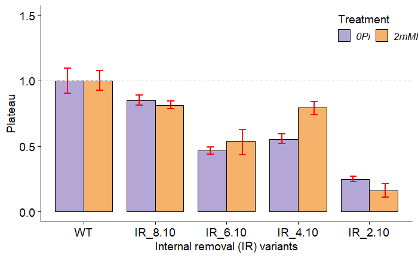

```r
#ggsave("output/TrunV_ori_rel_max.png", width = 10.16, height = 2)



TrunV.rel %>%
  filter(!is.na(new_median), genotype != "rescue") %>%
  ggplot(aes(x = Genotype, y = rel_red, fill = Treatment, pattern = Treatment)) + bar.list.no.stat +
  geom_bar_pattern(stat = "summary", fun = "mean",
                   position = position_dodge(preserve = "single"),
                   color = "black",
                   pattern_fill = "black",
                   pattern_angle = 45,
                   pattern_density = 0.1,  # 0.1
                   pattern_spacing = 0.04,  # 0.025
                   pattern_key_scale_factor = 1,
                   width=0.8) +
  scale_fill_manual(values = c("#b4a7d6ff","#f6b26bff")) +
  scale_pattern_manual(values = c(`0Pi` = "stripe", `2mMH2O2` = "none")) +
  geom_errorbar(stat = "summary", fun.data = mean_cl_boot, width = 0.2, color = "Red", linewidth = 1, position =
                  position_dodge(width = .9)) +
  scale_y_continuous(limits = c(0, 1.5)) +
  #geom_jitter(width = 0.3) +
  geom_hline(yintercept = 1, col = "gray", linetype = "dashed") +
  xlab("Internal removal (IR) variants") +
  ylab("Plateau") +
  guides(fill = guide_legend(nrow = 1)) +
  theme(strip.background = element_rect(colour="black", fill="white", size=1, linetype="solid"), legend.position=c(0.8,0.9))
```

```r
#ggsave("output/TrunV_red_rel_max.png", width = 10.16, height = 2)
```

### test epistasis effect between all IR variants

# Basal

```r
full.model.pi <- lm(rel_base ~ beta_2.4 + beta_4.6 + beta_6.8 + beta_8.10 +
                 beta_2.4:beta_4.6 + beta_4.6:beta_6.8 + beta_6.8:beta_8.10, data = bas.rel.pi)
base.model.pi <- lm(rel_base ~ 1, data = bas.rel.pi)

# 2mM H2O2:
full.model.oxi <- lm(rel_base ~ beta_2.4 + beta_4.6 + beta_6.8 + beta_8.10 +
                 beta_2.4:beta_4.6 + beta_4.6:beta_6.8 + beta_6.8:beta_8.10, data = bas.rel.oxi)
base.model.oxi <- lm(rel_base ~ 1, data = bas.rel.oxi)

# all treatment:
full.model <- lm(rel_base ~ beta_2.4 + beta_4.6 + beta_6.8 + beta_8.10 +
                beta_2.4:beta_4.6 + beta_4.6:beta_6.8 + beta_6.8:beta_8.10, data = bas.rel)
base.model <- lm(rel_base ~ 1, data = bas.rel)

#choose a model by AIC in a stepwise algorithm
# forward
step(base.model.pi, scope=list(upper=full.model.pi,lower=~1),direction="forward")
```

```
Start:  AIC=-249.09
rel_base ~ 1

            Df Sum of Sq     RSS     AIC
+ beta_8.10  1    9.3135  5.4931 -366.08
+ beta_6.8   1    2.8850 11.9215 -273.10
+ beta_4.6   1    1.0520 13.7545 -255.94
+ beta_2.4   1    0.4880 14.3186 -251.11
<none>                   14.8065 -249.09

Step:  AIC=-366.08
rel_base ~ beta_8.10

           Df Sum of Sq    RSS     AIC
+ beta_2.4  1   1.50752 3.9855 -402.58
+ beta_4.6  1   0.42597 5.0671 -373.77
+ beta_6.8  1   0.31774 5.1753 -371.23
<none>                  5.4931 -366.08

Step:  AIC=-402.58
rel_base ~ beta_8.10 + beta_2.4

           Df Sum of Sq    RSS     AIC
+ beta_6.8  1  0.089034 3.8965 -403.29
<none>                  3.9855 -402.58
+ beta_4.6  1  0.000102 3.9854 -400.58

Step:  AIC=-403.29
rel_base ~ beta_8.10 + beta_2.4 + beta_6.8

                     Df Sum of Sq    RSS     AIC
+ beta_6.8:beta_8.10  1   0.46910 3.4274 -416.68
<none>                            3.8965 -403.29
+ beta_4.6            1   0.01144 3.8851 -401.64

Step:  AIC=-416.68
rel_base ~ beta_8.10 + beta_2.4 + beta_6.8 + beta_8.10:beta_6.8

           Df  Sum of Sq    RSS     AIC
<none>                   3.4274 -416.68
+ beta_4.6  1 1.4413e-05 3.4274 -414.68

Call:
lm(formula = rel_base ~ beta_8.10 + beta_2.4 + beta_6.8 + beta_8.10:beta_6.8,
    data = bas.rel.pi)

Coefficients:
       (Intercept)           beta_8.10            beta_2.4            beta_6.8  beta_8.10:beta_6.8
           0.17348             0.43369             0.25306            -0.09997             0.28573
```

```r
step(base.model.oxi, scope = list(upper = full.model.oxi, lower =~1), direction = "forward")
```

```
Start:  AIC=-285.97
rel_base ~ 1

            Df Sum of Sq     RSS     AIC
+ beta_8.10  1    9.2249  6.0341 -407.36
+ beta_6.8   1    3.4170 11.8420 -317.69
+ beta_4.6   1    1.2816 13.9774 -295.64
+ beta_2.4   1    0.8767 14.3822 -291.84
<none>                   15.2590 -285.97

Step:  AIC=-407.36
rel_base ~ beta_8.10

           Df Sum of Sq    RSS     AIC
+ beta_2.4  1   2.06761 3.9665 -461.16
+ beta_6.8  1   0.72624 5.3079 -422.41
+ beta_4.6  1   0.61196 5.4222 -419.58
<none>                  6.0341 -407.36

Step:  AIC=-461.16
rel_base ~ beta_8.10 + beta_2.4

           Df Sum of Sq    RSS     AIC
+ beta_6.8  1   0.35083 3.6157 -471.47
<none>                  3.9665 -461.16
+ beta_4.6  1   0.00938 3.9571 -459.47

Step:  AIC=-471.47
rel_base ~ beta_8.10 + beta_2.4 + beta_6.8

                     Df Sum of Sq    RSS     AIC
+ beta_6.8:beta_8.10  1   0.32519 3.2905 -482.01
<none>                            3.6157 -471.47
+ beta_4.6            1   0.01309 3.6026 -469.96

Step:  AIC=-482.01
rel_base ~ beta_8.10 + beta_2.4 + beta_6.8 + beta_8.10:beta_6.8

           Df  Sum of Sq    RSS     AIC
<none>                   3.2905 -482.01
+ beta_4.6  1 1.9664e-06 3.2905 -480.01

Call:
lm(formula = rel_base ~ beta_8.10 + beta_2.4 + beta_6.8 + beta_8.10:beta_6.8,
    data = bas.rel.oxi)

Coefficients:
       (Intercept)           beta_8.10            beta_2.4            beta_6.8  beta_8.10:beta_6.8
           0.15466             0.41891             0.26786            -0.01648             0.22613
```

# Plateau

```r
round(summary(fit.pi.fwd)$coef, 5)
```

```
                   Estimate Std. Error  t value Pr(>|t|)
(Intercept)         0.09510    0.02381  3.99430  0.00012
beta_2.4            0.54971    0.02633 20.87444  0.00000
beta_6.8            0.40982    0.03971 10.32010  0.00000
beta_4.6           -0.15517    0.02846 -5.45263  0.00000
beta_8.10           0.01146    0.03538  0.32390  0.74661
beta_6.8:beta_8.10  0.07624    0.05010  1.52161  0.13090
```

```r
pi.fwd <- glance(fit.pi.fwd) # AIC = -162, BIC = -142,  R square adj = 0.8932

# 2mM h2o2:(both fwd and bwd)
fit.oxi.fwd <- lm(rel_red ~   beta_2.4 + beta_8.10 + beta_6.8 + beta_4.6 + beta_2.4:beta_4.6, data = plateau.oxi)
round(summary(fit.oxi.fwd)$coef, 5)
```

```
                  Estimate Std. Error  t value Pr(>|t|)
(Intercept)        0.06827    0.02115  3.22788  0.00159
beta_2.4           0.67479    0.03515 19.19757  0.00000
beta_8.10          0.21268    0.02142  9.92825  0.00000
beta_6.8           0.12524    0.02307  5.42840  0.00000
beta_4.6           0.22943    0.03489  6.57599  0.00000
beta_2.4:beta_4.6 -0.31915    0.04716 -6.76781  0.00000
```

```r
# Method 0: combine all IR variants for epistasis test
IR.epi <- bind_rows(ol.rel, TrunV.rel) %>% select(Genotype, Treatment, median, median_adj = new_median, genotype) %>%
  mutate(median = median/1000, beta_2.4 = 1, beta_4.6 = 1, beta_6.8 = 1, beta_8.10 = 1, TrunV_variable = 0)

# set up contrast matrix
IR.epi$beta_2.4 <- with(IR.epi, ifelse(Genotype == "IR_2.4" | Genotype == "IR_2.10", 0, 1))
IR.epi$beta_4.6 <- with(IR.epi, ifelse(Genotype == "IR_4.6" | Genotype == "IR_2.10"| Genotype == "IR_4.10", 0, 1))
IR.epi$beta_6.8 <- with(IR.epi, ifelse(Genotype == "IR_6.8" | Genotype == "IR_2.10"| Genotype == "IR_4.10"|
                                       Genotype == "IR_6.10", 0, 1))
IR.epi$beta_8.10 <- with(IR.epi, ifelse(Genotype == "IR_8.10" | Genotype == "IR_2.10"| Genotype == "IR_4.10"|
                                       Genotype == "IR_6.10", 0, 1))
IR.epi$TrunV_variable <- with(IR.epi, ifelse(genotype == "2V" | genotype == "4V"| genotype == "6V"|
                                       genotype == "8V", 1, 0))

IR.epi.pi <- IR.epi %>% filter(Genotype != "PC", Treatment == "0Pi")
IR.epi.oxi <- IR.epi %>% filter(Genotype != "PC", Treatment == "2mMH2O2")

# lm() fit
# original data withoud basal deduction
fit.pi <- IR.epi.pi %>% lm(median ~ beta_2.4 + beta_4.6 + beta_6.8 + beta_8.10 + TrunV_variable +
                             beta_2.4:beta_4.6 + beta_4.6:beta_6.8 + beta_6.8:beta_8.10, data = .)

round(summary(fit.pi)$coef, 3)

fit.oxi <- IR.epi.oxi %>% lm(median ~ beta_2.4 + beta_4.6 + beta_6.8 + beta_8.10  + TrunV_variable +
                             beta_2.4:beta_4.6 + beta_4.6:beta_6.8 + beta_6.8:beta_8.10, data = .)

round(summary(fit.oxi)$coef, 3)

# data deduced basal deduction
fit.pi <- IR.epi.pi %>% lm(median_adj ~ beta_2.4 + beta_4.6 + beta_6.8 + beta_8.10  + TrunV_variable +
                             beta_2.4:beta_4.6 + beta_4.6:beta_6.8 + beta_6.8:beta_8.10, data = .)

round(summary(fit.pi)$coef, 3)

fit.oxi <- IR.epi.oxi %>% lm(median_adj ~ beta_2.4 + beta_4.6 + beta_6.8 + beta_8.10  + TrunV_variable +
                             beta_2.4:beta_4.6 + beta_4.6:beta_6.8 + beta_6.8:beta_8.10, data = .)

round(summary(fit.oxi)$coef, 3)

# Conclusion:
# 1. absolute data revealed that no epitasis effect for - Pi (only additive effect); for oxidative stress epistatic effect identifed between all every 200 bps CRMs

# 2. Epistasis effect on Induction level: absolute data (basal reduced) revealed epitatic effect between 24 to 46, and 68 to 80 regardless of stress; epistatic effect between 46 to 68 only in H2O2 treatment

# 3. Epistasis effect on basal expression level?

# Note for contrast matrix: set -1 (IRs) vs 0 (WT) and set 0(IRs) vs 1 (WT) give the exact same result.
```

[output not shown]

# epitasis test between 600 - 800 bps and 800 - 1kb bps region

```r
# Method I: get IR_6.10, IR_6.8, IR_8.10 and WT for epistasis test
IR_6810.pi <- ol.rel %>% filter(Genotype %in% c("IR_6.8", "IR_8.10", "WT"), Treatment == "0Pi", Time == "240min")

IR_6810.oxi <- ol.rel %>% filter(Genotype %in% c("IR_6.8", "IR_8.10", "WT"), Treatment == "2mMH2O2", Time == "90min")

IR_610.pi <- TrunV.rel %>% filter(Genotype %in% c("IR_6.10", "IR_8.10", "WT"), Treatment == "0Pi", Time == "240min")
IR_610.oxi <- TrunV.rel %>% filter(Genotype %in% c("IR_6.10", "IR_8.10", "WT"), Treatment == "2mMH2O2", Time == "90min")

epi.pi <- bind_rows(IR_6810.pi, IR_610.pi)
epi.oxi <- bind_rows(IR_6810.oxi, IR_610.oxi)

epi.pi <- epi.pi %>% select(Genotype, Treatment, median, median_adj = new_median) %>%
  mutate(median = median/1000)
epi.oxi <- epi.oxi %>% select(Genotype, Treatment, median, median_adj = new_median) %>%
  mutate(median = median/1000)

# set up contrast matrix
epi <- bind_rows(epi.pi, epi.oxi) %>% mutate(beta_6.8 = 0, beta_8.10 = 0)
epi$beta_6.8 <- with(epi, ifelse(Genotype == "IR_6.8" | Genotype == "IR_6.10", -1, 0))
epi$beta_8.10 <- with(epi, ifelse(Genotype == "IR_8.10" | Genotype == "IR_6.10", -1, 0))

# make the statistical model
## original data (basal expression not deduced)
fit.ori.pi <- epi %>% filter(Treatment == "0Pi") %>% lm(median ~ beta_6.8 + beta_8.10 +
                      beta_6.8:beta_8.10,
                    data = .)
round(summary(fit.ori.pi)$coef, 3)

fit.ori.oxi <- epi %>% filter(Treatment == "2mMH2O2") %>% lm(median ~ beta_6.8 + beta_8.10 +
                                                               beta_6.8:beta_8.10, data = .)
round(summary(fit.ori.oxi)$coef, 3)

## deduced data
fit.adj.pi <- epi %>% filter(Treatment == "0Pi") %>% lm(median_adj ~ beta_6.8 + beta_8.10 +
                beta_6.8:beta_8.10,
              data = .)
round(summary(fit.adj.pi)$coef, 3)

fit.adj.oxi <- epi %>% filter(Treatment == "2mMH2O2") %>% lm(median_adj ~ beta_6.8 + beta_8.10 +
                                                               beta_6.8:beta_8.10, data = .)
round(summary(fit.adj.oxi)$coef, 3)

# Conclusion: (Without add in 8V data, 8V does not agree perfectly with 10OL) for the plaeteau, regardless of treatment and basal expression, 800-1000 bps and 600 to 800 bps has no significant interaction; with 8V and 10OL, they do have an epistasis effect.

#
```

[output not shown]

### slope/differetiation of the loess curve

```r
# plot & calculate the slope/differiation changes of OL:- Pi
# check the non-duplicated strain names
check.TrunV <- pi.TrunV.dat %>%  group_by(Genotype) %>% summarise(Strain = paste(unique(Strain), collapse = ', '))

# Can play the the genotype name to plot the diff(loess model)
test.pi <- pi.TrunV.dat %>% filter(Genotype == "IR_4.10") %>% loess(formula = new_median ~ new_time, span = 0.75, degree = 2)

x <- 0:240
px <- predict(test.pi, newdata = x)
px1 <- diff(px)
which.max(px1) # get the x value
```

```
[1] 75
```

```r
max(px1) # equals px1[which.max(px1)]
```

```
[1] 0.1043402
```

```r
par(mfrow=c(1, 2))
plot(x, px, main="loess model")

plot(x[-1], px1, main="diff(loess model)")
```

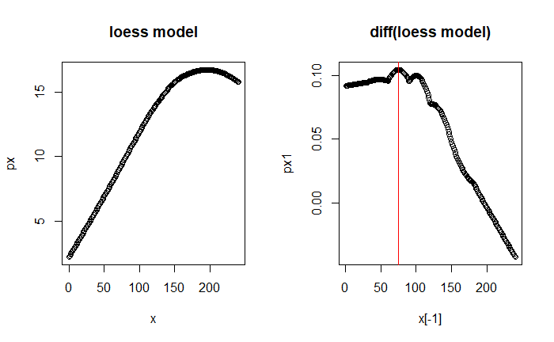

```r
abline(v=which.max(px1), col="red")
```

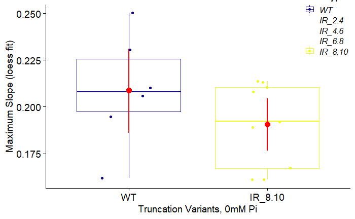

```r
# get the max slope and the respective tp for each sample into a dataframe: - Pi
pi.TrunV.slope <- data.frame(matrix(ncol=2,nrow=0, dimnames=list(NULL, c("slope", "Genotype"))))
row_cnt = 1
col_cnt = 1
for (x in names(levels)) {
  tmp.pi <- pi.TrunV.dat %>% filter(Genotype == x)
# get the loess function
  for (y in unique(pi.TrunV.dat$replicate)) {
    test.pi <- tmp.pi %>% filter(replicate == y)
    for (z in unique(test.pi$Strain)) {
      final.pi <- test.pi %>% filter(Strain == z) %>% loess(formula = new_median ~ new_time, span = 0.75, degree = 2)
      x_var <- 0:240
      px <- predict(final.pi, newdata = x_var)
      # perform differentiation
      tmp <- max(diff(px))
      gt_tmp <- x
      pi.TrunV.slope[row_cnt,col_cnt] <- tmp
      col_cnt = col_cnt + 1
      pi.TrunV.slope[row_cnt,col_cnt] <- gt_tmp
      col_cnt = 1
      row_cnt = row_cnt + 1
    }}}


pi.TrunV.slope <- pi.TrunV.slope %>%
  mutate(Genotype = factor(Genotype, levels =G.levels)) %>%
  mutate(Treatment = "0Pi")

# plot the slope of the curve: - Pi
pi.TrunV.slope %>%
  filter(!is.na(slope), Genotype != "PC") %>%
  ggplot(aes(x = Genotype, y = slope, color = Genotype)) + bar.list +
  geom_boxplot() +
  stat_summary(fun.data = "mean_cl_boot", color = "Red", linewidth = 1, size = 0.8) +
  geom_jitter(width = 0.2) +
  theme(legend.position="none") +
  scale_color_viridis_d(limits = names(levels.norescue), option = "plasma") +
  theme(legend.position=c(0.85,0.9)) +
  ylab("Maximum Slope (loess fit)") +
  xlab("Truncation Variants, 0mM Pi")
```

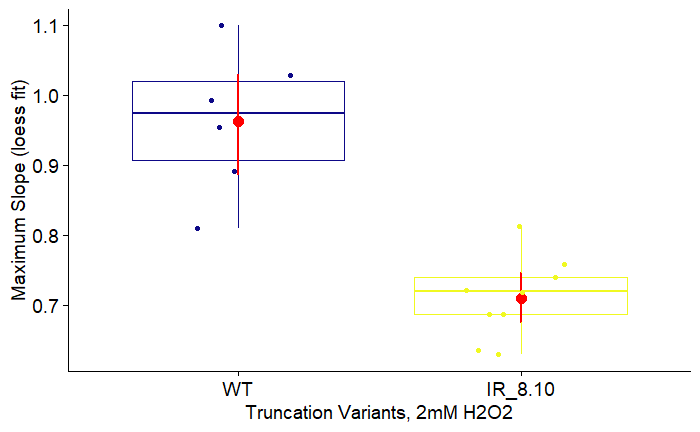

```r
#ggsave("output/TrunV_slope_0Pi.png", width = 6, height = 8)


# get the max slope and the respective tp for each sample into a dataframe: 2mM H2O2
oxi.TrunV.slope <- data.frame(matrix(ncol=2,nrow=0, dimnames=list(NULL, c("slope", "Genotype"))))
row_cnt = 1
col_cnt = 1
for (x in names(levels)) {
  tmp.oxi <- oxi.TrunV.dat %>% filter(Genotype == x)
# get the loess function
  for (y in unique(oxi.TrunV.dat$replicate)) {
    test.oxi <- tmp.oxi %>% filter(replicate == y)
    for (z in unique(test.oxi$Strain)) {
      final.oxi <- test.oxi %>% filter(Strain == z) %>% loess(formula = new_median ~ new_time, span = 0.75, degree = 2)
      x_var <- 0:240
      px <- predict(final.oxi, newdata = x_var)
      # perform differentiation
      tmp <- max(diff(px))
      gt_tmp <- x
      oxi.TrunV.slope[row_cnt,col_cnt] <- tmp
      col_cnt = col_cnt + 1
      oxi.TrunV.slope[row_cnt,col_cnt] <- gt_tmp
      col_cnt = 1
      row_cnt = row_cnt + 1
    }}}


oxi.TrunV.slope <- oxi.TrunV.slope %>%
  mutate(Genotype = factor(Genotype, levels =G.levels)) %>%
  mutate(Treatment = "2mMH2O2")

# plot the slope of the curve: - Pi
oxi.TrunV.slope %>%
  filter(!is.na(slope), Genotype != "PC") %>%
  ggplot(aes(x = Genotype, y = slope, color = Genotype)) + bar.list +
  geom_boxplot() +
  stat_summary(fun.data = "mean_cl_boot", color = "Red", linewidth = 1, size = 0.8) +
  geom_jitter(width = 0.2) +
  theme(legend.position="none") +
  scale_color_viridis_d(limits = names(levels.norescue), option = "plasma") +
  ylab("Maximum Slope (loess fit)") +
  xlab("Truncation Variants, 2mM H2O2")
```

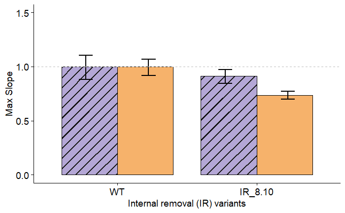

```r
#ggsave("output/TrunV_slope_oxi.png", width = 6, height = 8)


# get the maximum slope relative to the wt
pi.slope.rel <- pi.TrunV.slope %>% filter(!is.na(slope)) %>%
  group_by(Genotype) %>%
  mutate(mean_slope = mean(slope)) %>%
  mutate(wt_slope = mean(.[.$Genotype == "WT",]$mean_slope)) %>%
  mutate(rel_slope = slope/wt_slope)

oxi.slope.rel <- oxi.TrunV.slope %>% filter(!is.na(slope)) %>%
  group_by(Genotype) %>%
  mutate(mean_slope = mean(slope)) %>%
  mutate(wt_slope = mean(.[.$Genotype == "WT",]$mean_slope)) %>%
  mutate(rel_slope = slope/wt_slope)

# get the combined slope
TrunV.slope <- bind_rows(pi.slope.rel, oxi.slope.rel)

# plot the maximum slope relative to wt
TrunV.slope %>%
  filter(!is.na(rel_slope), Genotype != "PC") %>%
  ggplot(aes(x = Genotype, y = rel_slope, fill = Treatment, pattern = Treatment)) + bar.list.no.stat +
 geom_bar_pattern(stat = "summary", fun = "mean",
                   position = position_dodge(preserve = "single"),
                   color = "black",
                   pattern_fill = "black",
                   pattern_angle = 45,
                   pattern_density = 0.1,  # 0.1
                   pattern_spacing = 0.04,  # 0.025
                   pattern_key_scale_factor = 1,
                   width=0.8) +
  scale_fill_manual(values = c("#b4a7d6ff","#f6b26bff")) +
  scale_pattern_manual(values = c(`0Pi` = "stripe", `2mMH2O2` = "none")) +
  geom_errorbar(stat = "summary", fun.data = mean_cl_boot, width = 0.2, color = "Black", linewidth = 1, position =
                  position_dodge(width = .9)) +
  scale_y_continuous(limits = c(0, 1.5)) +
  #geom_jitter(width = 0.3) +
  geom_hline(yintercept = 1, col = "gray", linetype = "dashed") +
  xlab("Internal removal (IR) variants") +
  ylab("Max Slope") +
  guides(fill = guide_legend(nrow = 1)) +
  theme(strip.background = element_rect(colour="black", fill="white", size=1, linetype="solid"), legend.position= "none")
ggsave("output/TrunV_slope_rel_max.png", width = 10.16, height = 2)
```

#statstical test for max slope

```r
# add column genotype through Genotype name
rs.slope <- read.csv("input/rs_slope_rel.csv") %>% mutate(genotype = case_when(
  Genotype == "WT" ~ "wt",
  Genotype == "IS_2.4" ~ "RS1_24",
  Genotype == "IS_2.6" ~ "RS1_26",
  Genotype == "IS_2.8" ~ "RS1_28",
  Genotype == "IS_2.10" ~ "RS1_210",
))

TrunV.slope <- TrunV.slope %>%
  mutate(genotype = case_when(
    Genotype == "WT" ~ "wt",
    Genotype == "PC" ~ "rescue",
    Genotype == "IR_2.10" ~ "2V",
    Genotype == "IR_4.10" ~ "4V",
    Genotype == "IR_6.10" ~ "6V",
    Genotype == "IR_8.10" ~ "8V",
    TRUE ~ as.character(Genotype) # Default case, retaining the original value
  ))

ol.slope <- ol.slope %>% mutate(genotype = case_when(
  Genotype == "WT" ~ "wt",
  Genotype == "PC" ~ "rescue",
  Genotype == "IR_2.4" ~ "4OL",
  Genotype == "IR_4.6" ~ "6OL",
  Genotype == "IR_6.8" ~ "8OL",
  Genotype == "IR_8.10" ~ "10OL",
  TRUE ~ as.character(Genotype)
  ))


slope.rel <- bind_rows(TrunV.slope, ol.slope) %>% select(slope, rel_slope, Genotype, genotype, Treatment) %>%
             bind_rows(.,rs.slope) %>%
             mutate(beta_2.4 = 1, beta_4.6 = 1, beta_6.8 = 1, beta_8.10 = 1)

slope.rel$beta_2.4 <- with(slope.rel, ifelse(Genotype == "IR_2.4" | Genotype == "IR_2.10" | Genotype == "IS_2.4" |
                                         Genotype == "IS_2.6" | Genotype == "IS_2.8" | Genotype == "IS_2.10", 0, 1))
slope.rel$beta_4.6 <- with(slope.rel, ifelse(Genotype == "IR_4.6" | Genotype == "IR_2.10"| Genotype == "IR_4.10" |
                                         Genotype == "IS_2.6" | Genotype == "IS_2.8"| Genotype == "IS_2.10", 0, 1))
slope.rel$beta_6.8 <- with(slope.rel, ifelse(Genotype == "IR_6.8" | Genotype == "IR_2.10"| Genotype == "IR_4.10"|
                                         Genotype == "IR_6.10"| Genotype == "IS_2.8"| Genotype == "IS_2.10", 0, 1))
slope.rel$beta_8.10 <- with(slope.rel, ifelse(Genotype == "IR_8.10" | Genotype == "IR_2.10"| Genotype == "IR_4.10"|
                                         Genotype == "IR_6.10" | Genotype == "IS_2.10", 0, 1))


slope.rel.pi <- slope.rel %>% filter(Genotype != "PC", Treatment == "0Pi")
slope.rel.oxi <- slope.rel %>% filter(Genotype != "PC", Treatment == "2mMH2O2")



# variable selection for the lm
# - Pi:
full.model.pi <- lm(rel_slope ~ beta_2.4 + beta_4.6 + beta_6.8 + beta_8.10 +
                             beta_2.4:beta_4.6 + beta_4.6:beta_6.8 + beta_6.8:beta_8.10, data = slope.rel.pi)
base.model.pi <- lm(rel_slope ~ 1, data = slope.rel.pi)

# 2mM H2O2:
full.model.oxi <- lm(rel_slope ~ beta_2.4 + beta_4.6 + beta_6.8 + beta_8.10 +
                             beta_2.4:beta_4.6 + beta_4.6:beta_6.8 + beta_6.8:beta_8.10, data = slope.rel.oxi)
base.model.oxi <- lm(rel_slope ~ 1, data = slope.rel.oxi)

#choose a model by AIC in a stepwise algorithm
# forward
step(base.model.pi, scope=list(upper=full.model.pi,lower=~1),direction="forward")
```

```
Start:  AIC=-273.66
rel_slope ~ 1

            Df Sum of Sq     RSS     AIC
+ beta_6.8   1    6.2571  5.4784 -362.32
+ beta_2.4   1    5.6233  6.1123 -349.29
+ beta_4.6   1    3.1177  8.6179 -308.41
+ beta_8.10  1    0.4029 11.3327 -275.82
<none>                   11.7356 -273.66

Step:  AIC=-362.32
rel_slope ~ beta_6.8

            Df Sum of Sq    RSS     AIC
+ beta_2.4   1    4.2791 1.1993 -541.09
+ beta_4.6   1    0.5962 4.8822 -374.03
+ beta_8.10  1    0.1149 5.3636 -362.84
<none>                   5.4784 -362.32

Step:  AIC=-541.09
rel_slope ~ beta_6.8 + beta_2.4

            Df Sum of Sq    RSS     AIC
+ beta_4.6   1  0.065436 1.1339 -545.76
+ beta_8.10  1  0.033451 1.1659 -542.45
<none>                   1.1993 -541.09

Step:  AIC=-545.76
rel_slope ~ beta_6.8 + beta_2.4 + beta_4.6

                    Df Sum of Sq    RSS     AIC
+ beta_4.6:beta_6.8  1  0.059511 1.0744 -550.18
+ beta_8.10          1  0.040877 1.0930 -548.13
<none>                           1.1339 -545.76
+ beta_2.4:beta_4.6  1  0.003150 1.1307 -544.10

Step:  AIC=-550.18
rel_slope ~ beta_6.8 + beta_2.4 + beta_4.6 + beta_6.8:beta_4.6

                    Df Sum of Sq    RSS     AIC
```

[output cut: 12 more lines]

```
Step:  AIC=-561.01
rel_slope ~ beta_6.8 + beta_2.4 + beta_4.6 + beta_8.10 + beta_6.8:beta_4.6 +
    beta_6.8:beta_8.10

                    Df Sum of Sq     RSS     AIC
<none>                           0.94852 -561.01
+ beta_2.4:beta_4.6  1 0.0029429 0.94558 -559.37

Call:
lm(formula = rel_slope ~ beta_6.8 + beta_2.4 + beta_4.6 + beta_8.10 +
    beta_6.8:beta_4.6 + beta_6.8:beta_8.10, data = slope.rel.pi)

Coefficients:
       (Intercept)            beta_6.8            beta_2.4            beta_4.6           beta_8.10   beta_6.8:beta_4.6  beta_6.8:beta_8.10
           0.14238             0.27484             0.46000            -0.15716             0.03503             0.16715             0.07151
```

```r
step(base.model.oxi, scope = list(upper = full.model.oxi, lower =~1), direction = "forward")
```

```
Start:  AIC=-286.68
rel_slope ~ 1

            Df Sum of Sq     RSS     AIC
+ beta_2.4   1    7.7339  7.0836 -382.10
+ beta_4.6   1    4.4313 10.3862 -331.59
+ beta_6.8   1    2.7246 12.0929 -311.50
+ beta_8.10  1    2.0224 12.7951 -304.05
<none>                   14.8175 -286.68

Step:  AIC=-382.1
rel_slope ~ beta_2.4

            Df Sum of Sq    RSS     AIC
+ beta_8.10  1    3.6423 3.4413 -475.40
+ beta_6.8   1    1.7981 5.2854 -418.76
+ beta_4.6   1    0.8182 6.2653 -396.31
<none>                   7.0836 -382.10

Step:  AIC=-475.4
rel_slope ~ beta_2.4 + beta_8.10

           Df Sum of Sq    RSS     AIC
+ beta_6.8  1   0.47101 2.9703 -492.83
+ beta_4.6  1   0.22164 3.2196 -482.19
<none>                  3.4413 -475.40

Step:  AIC=-492.83
rel_slope ~ beta_2.4 + beta_8.10 + beta_6.8

                     Df Sum of Sq    RSS     AIC
+ beta_4.6            1  0.058129 2.9121 -493.44
+ beta_6.8:beta_8.10  1  0.046597 2.9237 -492.91
<none>                            2.9703 -492.83

Step:  AIC=-493.44
rel_slope ~ beta_2.4 + beta_8.10 + beta_6.8 + beta_4.6

                     Df Sum of Sq    RSS     AIC
+ beta_2.4:beta_4.6   1   0.38657 2.5256 -510.24
+ beta_6.8:beta_8.10  1   0.07059 2.8415 -494.68
<none>                            2.9121 -493.44
+ beta_4.6:beta_6.8   1   0.00000 2.9121 -491.44

Step:  AIC=-510.24
rel_slope ~ beta_2.4 + beta_8.10 + beta_6.8 + beta_4.6 + beta_2.4:beta_4.6

                     Df Sum of Sq    RSS     AIC
<none>                            2.5256 -510.24
+ beta_6.8:beta_8.10  1 0.0042736 2.5213 -508.46
+ beta_4.6:beta_6.8   1 0.0006851 2.5249 -508.27

Call:
lm(formula = rel_slope ~ beta_2.4 + beta_8.10 + beta_6.8 + beta_4.6 +
    beta_2.4:beta_4.6, data = slope.rel.oxi)

Coefficients:
      (Intercept)           beta_2.4          beta_8.10           beta_6.8           beta_4.6  beta_2.4:beta_4.6
          0.06095            0.65790            0.26991            0.08162            0.19564           -0.27076
```

```r
# backward: all prefers full model
step(full.model.pi, direction="backward")
```

```
Start:  AIC=-559.37
rel_slope ~ beta_2.4 + beta_4.6 + beta_6.8 + beta_8.10 + beta_2.4:beta_4.6 +
    beta_4.6:beta_6.8 + beta_6.8:beta_8.10

                     Df Sum of Sq     RSS     AIC
- beta_2.4:beta_4.6   1  0.002943 0.94852 -561.01
<none>                            0.94558 -559.37
- beta_6.8:beta_8.10  1  0.031088 0.97666 -557.53
- beta_4.6:beta_6.8   1  0.130956 1.07653 -545.94

Step:  AIC=-561.01
rel_slope ~ beta_2.4 + beta_4.6 + beta_6.8 + beta_8.10 + beta_4.6:beta_6.8 +
    beta_6.8:beta_8.10

                     Df Sum of Sq    RSS     AIC
<none>                            0.9485 -561.01
- beta_6.8:beta_8.10  1    0.0282 0.9767 -559.52
- beta_4.6:beta_6.8   1    0.1282 1.0767 -547.92
- beta_2.4            1    3.6428 4.5914 -375.34

Call:
lm(formula = rel_slope ~ beta_2.4 + beta_4.6 + beta_6.8 + beta_8.10 +
    beta_4.6:beta_6.8 + beta_6.8:beta_8.10, data = slope.rel.pi)

Coefficients:
       (Intercept)            beta_2.4            beta_4.6            beta_6.8           beta_8.10   beta_4.6:beta_6.8  beta_6.8:beta_8.10
           0.14238             0.46000            -0.15716             0.27484             0.03503             0.16715             0.07151
```

```r
step(full.model.oxi, direction = "backward")
```

```
Start:  AIC=-506.48
rel_slope ~ beta_2.4 + beta_4.6 + beta_6.8 + beta_8.10 + beta_2.4:beta_4.6 +
    beta_4.6:beta_6.8 + beta_6.8:beta_8.10

                     Df Sum of Sq    RSS     AIC
- beta_4.6:beta_6.8   1   0.00039 2.5213 -508.46
- beta_6.8:beta_8.10  1   0.00398 2.5249 -508.27
<none>                            2.5209 -506.48
- beta_2.4:beta_4.6   1   0.32017 2.8411 -492.70

Step:  AIC=-508.46
rel_slope ~ beta_2.4 + beta_4.6 + beta_6.8 + beta_8.10 + beta_2.4:beta_4.6 +
    beta_6.8:beta_8.10

                     Df Sum of Sq    RSS     AIC
- beta_6.8:beta_8.10  1   0.00427 2.5256 -510.24
<none>                            2.5213 -508.46
- beta_2.4:beta_4.6   1   0.32026 2.8415 -494.68

Step:  AIC=-510.24
rel_slope ~ beta_2.4 + beta_4.6 + beta_6.8 + beta_8.10 + beta_2.4:beta_4.6

                    Df Sum of Sq    RSS     AIC
<none>                           2.5256 -510.24
- beta_6.8           1   0.14863 2.6742 -504.69
- beta_2.4:beta_4.6  1   0.38657 2.9121 -493.44
- beta_8.10          1   1.88732 4.4129 -438.57

Call:
lm(formula = rel_slope ~ beta_2.4 + beta_4.6 + beta_6.8 + beta_8.10 +
    beta_2.4:beta_4.6, data = slope.rel.oxi)

Coefficients:
      (Intercept)           beta_2.4           beta_4.6           beta_6.8          beta_8.10  beta_2.4:beta_4.6
          0.06095            0.65790            0.19564            0.08162            0.26991           -0.27076
```

```r
#the best forward and backward stepwise selected model: (better than full model)
# - Pi: (both fwd and bwd)
fit.pi.fwd <-   lm(rel_slope ~  beta_6.8 + beta_2.4 + beta_4.6 + beta_8.10 + beta_6.8:beta_4.6 +
                               beta_6.8:beta_8.10, data = slope.rel.pi)
round(summary(fit.pi.fwd)$coef, 5)
```

```
                   Estimate Std. Error  t value Pr(>|t|)
(Intercept)         0.14238    0.01876  7.58985  0.00000
beta_6.8            0.27484    0.04262  6.44865  0.00000
beta_2.4            0.46000    0.02218 20.73987  0.00000
beta_4.6           -0.15716    0.03353 -4.68706  0.00001
beta_8.10           0.03503    0.02800  1.25116  0.21348
beta_6.8:beta_4.6   0.16715    0.04296  3.89064  0.00017
beta_6.8:beta_8.10  0.07151    0.03920  1.82416  0.07079
```

```r
pi.fwd <- glance(fit.pi.fwd) # AIC = -221, BIC = -199 , R square adj = 0.9148

# 2mM h2o2:(both fwd and bwd)
fit.oxi.fwd <- lm(rel_slope ~   beta_2.4 + beta_8.10 + beta_6.8 + beta_4.6 + beta_2.4:beta_4.6, data = slope.rel.oxi)
round(summary(fit.oxi.fwd)$coef, 5)
```

```
                  Estimate Std. Error  t value Pr(>|t|)
(Intercept)        0.06095    0.02744  2.22096  0.02814
beta_2.4           0.65790    0.04658 14.12360  0.00000
beta_8.10          0.26991    0.02782  9.70351  0.00000
beta_6.8           0.08162    0.02997  2.72307  0.00739
beta_4.6           0.19564    0.04528  4.32065  0.00003
beta_2.4:beta_4.6 -0.27076    0.06166 -4.39159  0.00002
```

```r
oxi.fwd <- glance(fit.oxi.fwd) # AIC = -133, BIC = -113 , R square adj = 0.8228

# full model
# - Pi:
fit.pi <- lm(rel_slope ~  beta_2.4 + beta_6.8 + beta_4.6 + beta_8.10 +
               beta_2.4:beta_4.6 + beta_4.6:beta_6.8 + beta_6.8:beta_8.10, data = slope.rel.pi)
#round(summary(fit.pi)$coef, 3)
pi <- glance(fit.pi) # AIC = -219, BIC = -194 , R square adj = 0.9143


# 2mM H2O2:
fit.oxi <- lm(rel_slope ~ beta_2.4 + beta_4.6 + beta_6.8 + beta_8.10 +
                             beta_2.4:beta_4.6 + beta_4.6:beta_6.8 + beta_6.8:beta_8.10, data = slope.rel.oxi)
#round(summary(fit.oxi)$coef, 3)
oxi <- glance(fit.oxi) # AIC = -129, BIC = -103 , R square adj = 0.8203
```

# combine tP and dP variants for epistasis test (max slope & basal)

```r
# combine - Pi and H2O2: (bwd selection)
fit.all <- bas.rel.no_rp  %>% lm(rel_base ~ beta_2.4 + beta_4.6 + beta_6.8 + beta_8.10 +
                             beta_2.4:beta_4.6 + beta_4.6:beta_6.8 + beta_6.8:beta_8.10, data = .)
round(summary(fit.all)$coef, 5)
```

```
                   Estimate Std. Error  t value Pr(>|t|)
(Intercept)         0.29364    0.01804 16.27671  0.00000
beta_2.4            0.09160    0.02853  3.21135  0.00158
beta_4.6           -0.02699    0.03293 -0.81970  0.41352
beta_6.8            0.31286    0.03480  8.99030  0.00000
beta_8.10           0.69732    0.02459 28.36316  0.00000
beta_2.4:beta_4.6  -0.12136    0.03531 -3.43700  0.00074
beta_4.6:beta_6.8  -0.18041    0.03723 -4.84532  0.00000
beta_6.8:beta_8.10 -0.06668    0.03015 -2.21176  0.02829
```

```r
full <- glance(fit.all) #  AIC = -407, BIC = -378, R square adj = 0.96
```

#separately model three series for main effect

```r
OL.levels <- c("wt","4OL", "6OL", "8OL", "10OL")
TrunV.levels <- c("wt","2V", "4V", "6V", "8V")
RS.levels <- c("wt","RS1_24","RS1_26","RS1_28","RS1_210")

# OL variants
## basal
# - Pi:
bas.rel.ol.pi <- bas.rel %>% filter(genotype %in% OL.levels, Treatment == "0Pi")

fit.ol.pi <- lm(rel_base ~   beta_2.4 + beta_4.6 +  beta_6.8 + beta_8.10, data = bas.rel.ol.pi)
round(summary(fit.ol.pi)$coef, 5)


# 2mM h2o2:
bas.rel.ol.oxi <- bas.rel %>% filter(genotype %in% OL.levels, Treatment == "2mMH2O2")

fit.ol.oxi <- lm(rel_base ~   beta_2.4 + beta_4.6 +  beta_6.8 + beta_8.10, data = bas.rel.ol.oxi )
round(summary(fit.ol.oxi)$coef, 5)


# combined:
bas.rel.ol <- bas.rel %>% filter(genotype %in% OL.levels)
fit.ol <- lm(rel_base ~   beta_2.4 + beta_4.6 +  beta_6.8 + beta_8.10, data = bas.rel.ol)
round(summary(fit.ol)$coef, 5)


## plateau
plateau.rel.ol.pi <- plateau %>% filter(genotype %in% OL.levels, Treatment == "0Pi")
plateau.rel.ol.oxi <- plateau %>% filter(genotype %in% OL.levels, Treatment == "2mMH2O2")

# - Pi
fit.ol.pi <- lm(rel_red ~   beta_2.4 + beta_4.6 +  beta_6.8 + beta_8.10, data = plateau.rel.ol.pi )
round(summary(fit.ol.pi)$coef, 5)

# 2mM H2O2:
fit.ol.oxi <- lm(rel_red ~   beta_2.4 + beta_4.6 +  beta_6.8 + beta_8.10, data = plateau.rel.ol.oxi )
round(summary(fit.ol.oxi)$coef, 5)


## max slope
slope.rel.ol.pi <- slope.rel %>% filter(genotype %in% OL.levels, Treatment == "0Pi")
slope.rel.ol.oxi <- slope.rel %>% filter(genotype %in% OL.levels, Treatment == "2mMH2O2")

# - Pi
fit.ol.pi <- lm(rel_slope ~   beta_2.4 + beta_4.6 +  beta_6.8 + beta_8.10, data = slope.rel.ol.pi )
round(summary(fit.ol.pi)$coef, 5)

# 2mM H2O2:
fit.ol.oxi <- lm(rel_slope ~   beta_2.4 + beta_4.6 +  beta_6.8 + beta_8.10, data = slope.rel.ol.oxi )
round(summary(fit.ol.oxi)$coef, 5)


# Truancation variants
## basal
# - Pi:
bas.rel.pi <- bas.rel %>% filter(genotype %in% TrunV.levels, Treatment == "0Pi")

fit.pi <- lm(rel_base ~   beta_2.4 + beta_4.6 +  beta_6.8 + beta_8.10, data = bas.rel.pi)
round(summary(fit.pi)$coef, 5)


# 2mM h2o2:
bas.rel.oxi <- bas.rel %>% filter(genotype %in% TrunV.levels, Treatment == "2mMH2O2")

fit.oxi <- lm(rel_base ~   beta_2.4 + beta_4.6 +  beta_6.8 + beta_8.10, data = bas.rel.oxi )
round(summary(fit.oxi)$coef, 5)


# combined:
bas.all <- bas.rel %>% filter(genotype %in% TrunV.levels)
fit.bas <- lm(rel_base ~   beta_2.4 + beta_4.6 +  beta_6.8 + beta_8.10, data = bas.all)
round(summary(fit.bas)$coef, 5)


## plateau
plateau.rel.pi <- plateau %>% filter(genotype %in% TrunV.levels, Treatment == "0Pi")
plateau.rel.oxi <- plateau %>% filter(genotype %in% TrunV.levels, Treatment == "2mMH2O2")

# - Pi
fit.pi <- lm(rel_red ~   beta_2.4 + beta_4.6 +  beta_6.8 + beta_8.10, data = plateau.rel.pi )
round(summary(fit.pi)$coef, 5)

# 2mM H2O2:
fit.oxi <- lm(rel_red ~   beta_2.4 + beta_4.6 +  beta_6.8 + beta_8.10, data = plateau.rel.oxi )
round(summary(fit.oxi)$coef, 5)


## max slope
slope.rel.pi <- slope.rel %>% filter(genotype %in% TrunV.levels, Treatment == "0Pi")
slope.rel.oxi <- slope.rel %>% filter(genotype %in% TrunV.levels, Treatment == "2mMH2O2")

# - Pi
fit.pi <- lm(rel_slope ~   beta_2.4 + beta_4.6 +  beta_6.8 + beta_8.10, data = slope.rel.pi )
round(summary(fit.pi)$coef, 5)

# 2mM H2O2:
fit.oxi <- lm(rel_slope ~   beta_2.4 + beta_4.6 +  beta_6.8 + beta_8.10, data = slope.rel.oxi )
round(summary(fit.oxi)$coef, 5)



# RS variants
## basal
# - Pi:
bas.rel.pi <- bas.rel %>% filter(genotype %in% RS.levels, Treatment == "0Pi")

fit.pi <- lm(rel_base ~   beta_2.4 + beta_4.6 +  beta_6.8 + beta_8.10, data = bas.rel.pi)
round(summary(fit.pi)$coef, 5)


# 2mM h2o2:
bas.rel.oxi <- bas.rel %>% filter(genotype %in% RS.levels, Treatment == "2mMH2O2")

fit.oxi <- lm(rel_base ~   beta_2.4 + beta_4.6 +  beta_6.8 + beta_8.10, data = bas.rel.oxi )
round(summary(fit.oxi)$coef, 5)


# combined:
bas.all <- bas.rel %>% filter(genotype %in% RS.levels)
fit.bas <- lm(rel_base ~   beta_2.4 + beta_4.6 +  beta_6.8 + beta_8.10, data = bas.all)
round(summary(fit.bas)$coef, 5)


## plateau
plateau.rel.pi <- plateau %>% filter(genotype %in% RS.levels, Treatment == "0Pi")
plateau.rel.oxi <- plateau %>% filter(genotype %in% RS.levels, Treatment == "2mMH2O2")

# - Pi
fit.pi <- lm(rel_red ~   beta_2.4 + beta_4.6 +  beta_6.8 + beta_8.10, data = plateau.rel.pi )
round(summary(fit.pi)$coef, 5)

# 2mM H2O2:
fit.oxi <- lm(rel_red ~   beta_2.4 + beta_4.6 +  beta_6.8 + beta_8.10, data = plateau.rel.oxi )
round(summary(fit.oxi)$coef, 5)


## max slope
slope.rel.pi <- slope.rel %>% filter(genotype %in% RS.levels, Treatment == "0Pi")
slope.rel.oxi <- slope.rel %>% filter(genotype %in% RS.levels, Treatment == "2mMH2O2")

# - Pi
fit.pi <- lm(rel_slope ~   beta_2.4 + beta_4.6 +  beta_6.8 + beta_8.10, data = slope.rel.pi )
round(summary(fit.pi)$coef, 5)

# 2mM H2O2:
fit.oxi <- lm(rel_slope ~   beta_2.4 + beta_4.6 +  beta_6.8 + beta_8.10, data = slope.rel.oxi )
round(summary(fit.oxi)$coef, 5)
```

#Plot regulatory information loss with all variants

```r
#new.levels <- c("WT", "IS_2.4","IR_2.4","IR_4.6","IR_6.8","IR_8.10")
new.levels <- c("WT", "IR_8.10", "IR_6.8", "IR_4.6", "IR_2.4", "IS_2.4")

# new.levels
new.plateau <- plateau %>% filter(Genotype %in% c("WT", "IS_2.4","IR_2.4","IR_4.6","IR_6.8","IR_8.10")) %>%
  select(Genotype, Time, genotype, rel_ori,rel_red, Treatment) %>%
  mutate(loss_ori = 1 - rel_ori, loss_red = 1 - rel_red) %>%
  mutate(Genotype = factor(Genotype, levels = new.levels))

new.slope <- slope.rel %>% filter(Genotype %in% c("WT", "IS_2.4","IR_2.4","IR_4.6","IR_6.8","IR_8.10")) %>%
  select(Genotype, rel_slope, Treatment) %>%
  mutate(loss_slope = 1 - rel_slope) %>%
  mutate(Genotype = factor(Genotype, levels = new.levels))

new.bas <- bas.rel %>% filter(Genotype %in% c("WT", "IS_2.4","IR_2.4","IR_4.6","IR_6.8","IR_8.10")) %>%
  select(Genotype, Time, rel_base, Treatment,genotype) %>%
  mutate(loss_base = 1 - rel_base) %>%
  mutate(Genotype = factor(Genotype, levels = new.levels))

# plot regulatory infomation loss
new.plateau %>%
  filter(!is.na(loss_red), Genotype != "PC") %>%
  ggplot(aes(x = Genotype, y = loss_red, fill = Treatment, pattern = Treatment)) + bar.list.no.stat +
 geom_bar_pattern(stat = "summary", fun = "mean",
                   position = position_dodge(preserve = "single"),
                   color = "black",
                   pattern_fill = "black",
                   pattern_angle = 45,
                   pattern_density = 0.1,  # 0.1
                   pattern_spacing = 0.04,  # 0.025
                   pattern_key_scale_factor = 1,
                   width=0.8) +
  scale_fill_manual(values = c("#b4a7d6ff","#f6b26bff"),labels = c("-Pi", bquote(~H[2]*O[2]))) +
  scale_pattern_manual(values = c(`0Pi` = "stripe", `2mMH2O2` = "none"),labels = c("-Pi", bquote(~H[2]*O[2]))) +
  geom_errorbar(stat = "summary", fun.data = mean_cl_boot, width = 0.2, color = "Black", linewidth = 1, position =
                  position_dodge(width = .9)) +
  scale_y_continuous(limits = c(-0.25, 1.0)) +
  #geom_jitter(width = 0.3) +
  geom_hline(yintercept = 1, col = "gray", linetype = "dashed") +
  xlab("promoter bashing variants") +
  ylab("Plateau loss \n (Relative to WT)") +
  guides(fill = guide_legend(nrow = 1, title = NULL), pattern = guide_legend(title = NULL)) +
  theme(strip.background = element_rect(colour="black", fill="white", size=1, linetype="solid"),
        legend.position= c(0.02, 0.9),
        axis.title.x=element_blank())
#ggsave("output/plateau_loss.png", width = 7.2, height = 2)

new.slope %>%
  filter(!is.na(loss_slope), Genotype != "PC") %>%
  ggplot(aes(x = Genotype, y = loss_slope, fill = Treatment, pattern = Treatment)) + bar.list.no.stat +
 geom_bar_pattern(stat = "summary", fun = "mean",
                   position = position_dodge(preserve = "single"),
                   color = "black",
                   pattern_fill = "black",
                   pattern_angle = 45,
                   pattern_density = 0.1,  # 0.1
                   pattern_spacing = 0.04,  # 0.025
                   pattern_key_scale_factor = 1,
                   width=0.8) +
  scale_fill_manual(values = c("#b4a7d6ff","#f6b26bff")) +
  scale_pattern_manual(values = c(`0Pi` = "stripe", `2mMH2O2` = "none")) +
  geom_errorbar(stat = "summary", fun.data = mean_cl_boot, width = 0.2, color = "Black", linewidth = 1, position =
                  position_dodge(width = .9)) +
  scale_y_continuous(limits = c(-0.25, 1.0)) +
  #geom_jitter(width = 0.3) +
  geom_hline(yintercept = 1, col = "gray", linetype = "dashed") +
  xlab("promoter bashing variants") +
  ylab("Max slope loss \n (Relative to WT)") +
  guides(fill = guide_legend(nrow = 1)) +
  theme(strip.background = element_rect(colour="black", fill="white", size=1, linetype="solid"),
        legend.position= "none",
        axis.title.x=element_blank())
#ggsave("output/slope_loss.png", width = 7.2, height = 2)

new.bas %>%
  filter(!is.na(loss_base), Genotype != "PC") %>%
  ggplot(aes(x = Genotype, y = loss_base, fill = Treatment, pattern = Treatment)) + bar.list.no.stat +
 geom_bar_pattern(stat = "summary", fun = "mean",
                   position = position_dodge(preserve = "single"),
                   color = "black",
                   pattern_fill = "black",
                   pattern_angle = 45,
                   pattern_density = 0.1,  # 0.1
                   pattern_spacing = 0.04,  # 0.025
                   pattern_key_scale_factor = 1,
                   width=0.8) +
  scale_fill_manual(values = c("#b4a7d6ff","#f6b26bff"),labels = c("-Pi", bquote(~H[2]*O[2]))) +
  scale_pattern_manual(values = c(`0Pi` = "stripe", `2mMH2O2` = "none"),labels = c("-Pi", bquote(~H[2]*O[2]))) +
  geom_errorbar(stat = "summary", fun.data = mean_cl_boot, width = 0.2, color = "Black", linewidth = 1, position =
                  position_dodge(width = .9)) +
  scale_y_continuous(limits = c(-0.5, 1.0)) +
  #geom_jitter(width = 0.3) +
  geom_hline(yintercept = 1, col = "gray", linetype = "dashed") +
  xlab("promoter bashing variants") +
  ylab("Basal exp loss \n (Relative to WT)") +
  guides(fill = guide_legend(nrow = 1, title = NULL), pattern = guide_legend(title = NULL)) +
  theme(strip.background = element_rect(colour="black", fill="white", size=1, linetype="solid"),
        legend.position= c(0.02, 0.9),
        axis.title.x=element_blank())
#ggsave("output/base_loss.png", width = 10.16, height = 2)
```

# plot CRM4.6 related three features relative to WT

```r
#CRM4.6
CRM46.levels <- c("WT","IS_2.4","IS_2.6","IR_4.10","IR_6.10")

## Plateau
CRM46.plateau <- plateau %>% filter(Genotype %in% CRM46.levels) %>%
                 select(Genotype,Time,genotype,rel_ori,rel_red,Treatment) %>%
                 mutate(loss_ori = 1 - rel_ori, loss_red = 1 - rel_red, Genotype = factor(Genotype, levels = CRM46.levels))

## Slope
CRM46.slope <- slope.rel %>% filter(Genotype %in% CRM46.levels) %>%
               select(Genotype, rel_slope, Treatment) %>%
               mutate(loss_slope = 1 - rel_slope, Genotype = factor(Genotype, levels = CRM46.levels))

## Basal expression
CRM46.bas <- bas.rel %>% filter(Genotype %in% CRM46.levels) %>%
             select(Genotype, Time, rel_base, Treatment,genotype) %>%
             mutate(loss_base = 1 - rel_base, Genotype = factor(Genotype, levels = CRM46.levels))



# Information loss relative to WT
## CRM4.6 related Plateau loss
CRM46.plateau %>%
  filter(!is.na(loss_red), Genotype != "PC") %>%
  ggplot(aes(x = Genotype, y = loss_red, fill = Treatment, pattern = Treatment)) + bar.list.no.stat +
 geom_bar_pattern(stat = "summary", fun = "mean",
                   position = position_dodge(preserve = "single"),
                   color = "black",
                   pattern_fill = "black",
                   pattern_angle = 45,
                   pattern_density = 0.1,  # 0.1
                   pattern_spacing = 0.04,  # 0.025
                   pattern_key_scale_factor = 1,
                   width=0.8) +
  scale_fill_manual(values = c("#b4a7d6ff","#f6b26bff"),labels = c("-Pi", bquote(~H[2]*O[2]))) +
  scale_pattern_manual(values = c(`0Pi` = "stripe", `2mMH2O2` = "none"),labels = c("-Pi", bquote(~H[2]*O[2]))) +
  geom_errorbar(stat = "summary", fun.data = mean_cl_boot, width = 0.2, color = "Black", linewidth = 1, position =
                  position_dodge(width = .9)) +
  scale_y_continuous(breaks = seq(-0.4,1.0,0.2)) +
  #geom_jitter(width = 0.3) +
  geom_hline(yintercept = 1, col = "gray", linetype = "dashed") +
  xlab("promoter bashing variants") +
  ylab("Plateau loss \n (Relative to WT)") +
  guides(fill = guide_legend(nrow = 1, title = NULL), pattern = guide_legend(title = NULL)) +
  theme(strip.background = element_rect(colour="black", fill="white", size=1, linetype="solid"),
        legend.position= c(0.02, 0.9),
        axis.title.x=element_blank())
ggsave("output/CRM46_plateau_loss.png", width = 7.2, height = 2)

## plot CRM4.6 related max slope
CRM46.slope %>%
  filter(!is.na(loss_slope), Genotype != "PC") %>%
  ggplot(aes(x = Genotype, y = loss_slope, fill = Treatment, pattern = Treatment)) + bar.list.no.stat +
 geom_bar_pattern(stat = "summary", fun = "mean",
                   position = position_dodge(preserve = "single"),
                   color = "black",
                   pattern_fill = "black",
                   pattern_angle = 45,
                   pattern_density = 0.1,  # 0.1
                   pattern_spacing = 0.04,  # 0.025
                   pattern_key_scale_factor = 1,
                   width=0.8) +
  scale_fill_manual(values = c("#b4a7d6ff","#f6b26bff")) +
  scale_pattern_manual(values = c(`0Pi` = "stripe", `2mMH2O2` = "none")) +
  geom_errorbar(stat = "summary", fun.data = mean_cl_boot, width = 0.2, color = "Black", linewidth = 1, position =
                  position_dodge(width = .9)) +
  scale_y_continuous(breaks = seq(-0.4,1.0,0.2)) +
  #geom_jitter(width = 0.3) +
  geom_hline(yintercept = 1, col = "gray", linetype = "dashed") +
  xlab("promoter bashing variants") +
  ylab("Max slope loss \n (Relative to WT)") +
  guides(fill = guide_legend(nrow = 1)) +
  theme(strip.background = element_rect(colour="black", fill="white", size=1, linetype="solid"),
        legend.position= "none",
        axis.title.x=element_blank())
ggsave("output/CRM46_slope_loss.png", width = 7.2, height = 2)

# CRM4.6 related basal exp
CRM46.bas %>%
  filter(!is.na(loss_base), Genotype != "PC") %>%
  ggplot(aes(x = Genotype, y = loss_base, fill = Treatment, pattern = Treatment)) + bar.list.no.stat +
 geom_bar_pattern(stat = "summary", fun = "mean",
                   position = position_dodge(preserve = "single"),
                   color = "black",
                   pattern_fill = "black",
                   pattern_angle = 45,
                   pattern_density = 0.1,  # 0.1
                   pattern_spacing = 0.04,  # 0.025
                   pattern_key_scale_factor = 1,
                   width=0.8) +
  scale_fill_manual(values = c("#b4a7d6ff","#f6b26bff"),labels = c("-Pi", bquote(~H[2]*O[2]))) +
  scale_pattern_manual(values = c(`0Pi` = "stripe", `2mMH2O2` = "none"),labels = c("-Pi", bquote(~H[2]*O[2]))) +
  geom_errorbar(stat = "summary", fun.data = mean_cl_boot, width = 0.2, color = "Black", linewidth = 1, position =
                  position_dodge(width = .9)) +
  scale_y_continuous(breaks = seq(-0.4,1.0,0.2)) +
  #geom_jitter(width = 0.3) +
  geom_hline(yintercept = 1, col = "gray", linetype = "dashed") +
  xlab("promoter bashing variants") +
  ylab("Basal exp loss \n (Relative to WT)") +
  guides(fill = guide_legend(nrow = 1, title = NULL), pattern = guide_legend(title = NULL)) +
  theme(strip.background = element_rect(colour="black", fill="white", size=1, linetype="solid"),
        legend.position= c(0.02, 0.9),
        axis.title.x=element_blank())
#ggsave("output/CRM46_base_loss.png", width = 10.16, height = 2)



# Relative to WT
## CRM4.6 related Plateau
CRM46.plateau %>%
  filter(!is.na(rel_red), Genotype != "PC") %>%
  ggplot(aes(x = Genotype, y = rel_red, fill = Treatment, pattern = Treatment)) + bar.list.no.stat +
 geom_bar_pattern(stat = "summary", fun = "mean",
                   position = position_dodge(preserve = "single"),
                   color = "black",
                   pattern_fill = "black",
                   pattern_angle = 45,
                   pattern_density = 0.1,  # 0.1
                   pattern_spacing = 0.04,  # 0.025
                   pattern_key_scale_factor = 1,
                   width=0.8) +
  scale_fill_manual(values = c("#b4a7d6ff","#f6b26bff"),labels = c("-Pi", bquote(~H[2]*O[2]))) +
  scale_pattern_manual(values = c(`0Pi` = "stripe", `2mMH2O2` = "none"),labels = c("-Pi", bquote(~H[2]*O[2]))) +
  geom_errorbar(stat = "summary", fun.data = mean_cl_boot, width = 0.2, color = "Black", linewidth = 1, position =
                  position_dodge(width = .9)) +
  scale_y_continuous(breaks = seq(-0.4,1.0,0.2)) +
  #geom_jitter(width = 0.3) +
  geom_hline(yintercept = 1, col = "gray", linetype = "dashed") +
  xlab("promoter bashing variants") +
  ylab("Plateau \n (Relative to WT)") +
  guides(fill = guide_legend(nrow = 1, title = NULL), pattern = guide_legend(title = NULL)) +
  theme(strip.background = element_rect(colour="black", fill="white", size=1, linetype="solid"),
        legend.position= c(0.02, 0.9),
        axis.title.x=element_blank())
#ggsave("output/CRM46_plateau.png", width = 7.2, height = 2)


## plot CRM4.6 related max slope
CRM46.slope %>%
  filter(!is.na(rel_slope), Genotype != "PC") %>%
  ggplot(aes(x = Genotype, y = rel_slope, fill = Treatment, pattern = Treatment)) + bar.list.no.stat +
 geom_bar_pattern(stat = "summary", fun = "mean",
                   position = position_dodge(preserve = "single"),
                   color = "black",
                   pattern_fill = "black",
                   pattern_angle = 45,
                   pattern_density = 0.1,  # 0.1
                   pattern_spacing = 0.04,  # 0.025
                   pattern_key_scale_factor = 1,
                   width=0.8) +
  scale_fill_manual(values = c("#b4a7d6ff","#f6b26bff")) +
  scale_pattern_manual(values = c(`0Pi` = "stripe", `2mMH2O2` = "none")) +
  geom_errorbar(stat = "summary", fun.data = mean_cl_boot, width = 0.2, color = "Black", linewidth = 1, position =
                  position_dodge(width = .9)) +
  scale_y_continuous(breaks = seq(-0.4,1.0,0.2)) +
  #geom_jitter(width = 0.3) +
  geom_hline(yintercept = 1, col = "gray", linetype = "dashed") +
  xlab("promoter bashing variants") +
  ylab("Max slope \n (Relative to WT)") +
  guides(fill = guide_legend(nrow = 1)) +
  theme(strip.background = element_rect(colour="black", fill="white", size=1, linetype="solid"),
        legend.position= "none",
        axis.title.x=element_blank())
#ggsave("output/CRM46_slope.png", width = 7.2, height = 2)

# CRM4.6 related basal exp
CRM46.bas %>%
  filter(!is.na(rel_base), Genotype != "PC") %>%
  ggplot(aes(x = Genotype, y = rel_base, fill = Treatment, pattern = Treatment)) + bar.list.no.stat +
 geom_bar_pattern(stat = "summary", fun = "mean",
                   position = position_dodge(preserve = "single"),
                   color = "black",
                   pattern_fill = "black",
                   pattern_angle = 45,
                   pattern_density = 0.1,  # 0.1
                   pattern_spacing = 0.04,  # 0.025
                   pattern_key_scale_factor = 1,
                   width=0.8) +
  scale_fill_manual(values = c("#b4a7d6ff","#f6b26bff"),labels = c("-Pi", bquote(~H[2]*O[2]))) +
  scale_pattern_manual(values = c(`0Pi` = "stripe", `2mMH2O2` = "none"),labels = c("-Pi", bquote(~H[2]*O[2]))) +
  geom_errorbar(stat = "summary", fun.data = mean_cl_boot, width = 0.2, color = "Black", linewidth = 1, position =
                  position_dodge(width = .9)) +
  scale_y_continuous(breaks = seq(-0.4,1.0,0.2)) +
  #geom_jitter(width = 0.3) +
  geom_hline(yintercept = 1, col = "gray", linetype = "dashed") +
  xlab("promoter bashing variants") +
  ylab("Basal exp \n (Relative to WT)") +
  guides(fill = guide_legend(nrow = 1, title = NULL), pattern = guide_legend(title = NULL)) +
  theme(strip.background = element_rect(colour="black", fill="white", size=1, linetype="solid"),
        legend.position= c(0.02, 0.9),
        axis.title.x=element_blank())
#ggsave("output/CRM46_base.png", width = 10.16, height = 2)
```

# dPs

```r
dPs.levels <- c("wt", "10OL", "8OL", "6OL","4OL")


## Plateau loss
dPs.plateau <- plateau %>% filter(genotype %in% dPs.levels) %>%
                 select(Genotype,Time,genotype,rel_ori,rel_red,Treatment) %>%
                 mutate(loss_ori = 1 - rel_ori, loss_red = 1 - rel_red, genotype = factor(genotype, levels = dPs.levels))

## Slope loss
dPs.slope <- slope.rel %>% filter(genotype %in% dPs.levels) %>%
               select(Genotype, rel_slope, Treatment, genotype) %>%
               mutate(loss_slope = 1 - rel_slope, genotype = factor(genotype, levels = dPs.levels))



## Basal loss
new.bas <- bas.rel %>% filter(genotype %in% dPs.levels) %>%
  select(Genotype, Time, rel_base, Treatment,genotype) %>%
  mutate(loss_base = 1 - rel_base, genotype = factor(genotype, levels = dPs.levels))


# Plateau loss
dPs.plateau %>%
  filter(!is.na(loss_red), genotype != "PC") %>%
  ggplot(aes(x = genotype, y = loss_red, fill = Treatment, pattern = Treatment)) + bar.list.no.stat +
 geom_bar_pattern(stat = "summary", fun = "mean",
                   position = position_dodge(preserve = "single"),
                   color = "black",
                   pattern_fill = "black",
                   pattern_angle = 45,
                   pattern_density = 0.1,  # 0.1
                   pattern_spacing = 0.04,  # 0.025
                   pattern_key_scale_factor = 1,
                   width=0.8) +
  scale_fill_manual(values = c("#b4a7d6ff","#f6b26bff"),labels = c("-Pi", bquote(~H[2]*O[2]))) +
  scale_pattern_manual(values = c(`0Pi` = "stripe", `2mMH2O2` = "none"),labels = c("-Pi", bquote(~H[2]*O[2]))) +
  geom_errorbar(stat = "summary", fun.data = mean_cl_boot, width = 0.2, color = "Black", linewidth = 1, position =
                  position_dodge(width = .9)) +
  scale_y_continuous(breaks = seq(-0.5,1.0,0.5)) +
  #geom_jitter(width = 0.3) +
  geom_hline(yintercept = 1, col = "gray", linetype = "dashed") +
  xlab("promoter bashing variants") +
  ylab("Plateau loss \n (Relative to WT)") +
  guides(fill = guide_legend(nrow = 1, title = NULL), pattern = guide_legend(title = NULL)) +
  theme(strip.background = element_rect(colour="black", fill="white", size=1, linetype="solid"),
        legend.position= c(0.8, 0.9),
        axis.title.x=element_blank())
#ggsave("output/dPs_plateau_loss.png", width = 10.16, height = 2)

## dPs Max Slope loss
dPs.slope %>%
  filter(!is.na(loss_slope), Genotype != "PC") %>%
  ggplot(aes(x = genotype, y = loss_slope, fill = Treatment, pattern = Treatment)) + bar.list.no.stat +
 geom_bar_pattern(stat = "summary", fun = "mean",
                   position = position_dodge(preserve = "single"),
                   color = "black",
                   pattern_fill = "black",
                   pattern_angle = 45,
                   pattern_density = 0.1,  # 0.1
                   pattern_spacing = 0.04,  # 0.025
                   pattern_key_scale_factor = 1,
                   width=0.8) +
  scale_fill_manual(values = c("#b4a7d6ff","#f6b26bff")) +
  scale_pattern_manual(values = c(`0Pi` = "stripe", `2mMH2O2` = "none")) +
  geom_errorbar(stat = "summary", fun.data = mean_cl_boot, width = 0.2, color = "Black", linewidth = 1, position =
                  position_dodge(width = .9)) +
  scale_y_continuous(breaks = seq(-0.5,1.0,0.5)) +
  #geom_jitter(width = 0.3) +
  geom_hline(yintercept = 1, col = "gray", linetype = "dashed") +
  xlab("promoter bashing variants") +
  ylab("Max slope loss \n (Relative to WT)") +
  guides(fill = guide_legend(nrow = 1)) +
  theme(strip.background = element_rect(colour="black", fill="white", size=1, linetype="solid"),
        legend.position= "none",
        axis.title.x=element_blank())
ggsave("output/dPs_slope_loss.png", width = 10.16, height = 2)



# dPs basal loss plot
new.bas %>%
  filter(!is.na(loss_base), Genotype != "PC") %>%
  ggplot(aes(x = genotype, y = loss_base, fill = Treatment, pattern = Treatment)) + bar.list.no.stat +
 geom_bar_pattern(stat = "summary", fun = "mean",
                   position = position_dodge(preserve = "single"),
                   color = "black",
                   pattern_fill = "black",
                   pattern_angle = 45,
                   pattern_density = 0.1,  # 0.1
                   pattern_spacing = 0.04,  # 0.025
                   pattern_key_scale_factor = 1,
                   width=0.8) +
  scale_fill_manual(values = c("#b4a7d6ff","#f6b26bff"),labels = c("-Pi", bquote(~H[2]*O[2]))) +
  scale_pattern_manual(values = c(`0Pi` = "stripe", `2mMH2O2` = "none"),labels = c("-Pi", bquote(~H[2]*O[2]))) +
  geom_errorbar(stat = "summary", fun.data = mean_cl_boot, width = 0.2, color = "Black", linewidth = 1, position =
                  position_dodge(width = .9)) +
  scale_y_continuous(limits = c(-0.5, 1.0)) +
  #geom_jitter(width = 0.3) +
  geom_hline(yintercept = 1, col = "gray", linetype = "dashed") +
  xlab("promoter bashing variants") +
  ylab("Basal exp loss \n (Relative to WT)") +
  guides(fill = guide_legend(nrow = 1, title = NULL), pattern = guide_legend(title = NULL)) +
  theme(strip.background = element_rect(colour="black", fill="white", size=1, linetype="solid"),
        legend.position= "none",
        axis.title.x=element_blank())
#ggsave("output/base_loss_dPs.png", width = 10.16, height = 2)
```

# tPs

```r
tPs.levels <- c("wt", "8V", "6V", "4V","2V")


## Plateau loss
tPs.plateau <- plateau %>% filter(genotype %in% tPs.levels) %>%
                 select(Genotype,Time,genotype,rel_ori,rel_red,Treatment) %>%
                 mutate(loss_ori = 1 - rel_ori, loss_red = 1 - rel_red, genotype = factor(genotype, levels = tPs.levels))

## Slope loss
tPs.slope <- slope.rel %>% filter(genotype %in% tPs.levels) %>%
               select(Genotype, rel_slope, Treatment, genotype) %>%
               mutate(loss_slope = 1 - rel_slope, genotype = factor(genotype, levels = tPs.levels))



## Basal loss
new.bas <- bas.rel %>% filter(genotype %in% tPs.levels) %>%
  select(Genotype, Time, rel_base, Treatment,genotype) %>%
  mutate(loss_base = 1 - rel_base, genotype = factor(genotype, levels = tPs.levels))


# Plateau loss
tPs.plateau %>%
  filter(!is.na(loss_red), genotype != "PC") %>%
  ggplot(aes(x = genotype, y = loss_red, fill = Treatment, pattern = Treatment)) + bar.list.no.stat +
 geom_bar_pattern(stat = "summary", fun = "mean",
                   position = position_dodge(preserve = "single"),
                   color = "black",
                   pattern_fill = "black",
                   pattern_angle = 45,
                   pattern_density = 0.1,  # 0.1
                   pattern_spacing = 0.04,  # 0.025
                   pattern_key_scale_factor = 1,
                   width=0.8) +
  scale_fill_manual(values = c("#b4a7d6ff","#f6b26bff"),labels = c("-Pi", bquote(~H[2]*O[2]))) +
  scale_pattern_manual(values = c(`0Pi` = "stripe", `2mMH2O2` = "none"),labels = c("-Pi", bquote(~H[2]*O[2]))) +
  geom_errorbar(stat = "summary", fun.data = mean_cl_boot, width = 0.2, color = "Black", linewidth = 1, position =
                  position_dodge(width = .9)) +
  scale_y_continuous(breaks = seq(-0.5,1.0,0.5)) +
  #geom_jitter(width = 0.3) +
  geom_hline(yintercept = 1, col = "gray", linetype = "dashed") +
  xlab("promoter bashing variants") +
  ylab("Plateau loss \n (Relative to WT)") +
  guides(fill = guide_legend(nrow = 1, title = NULL), pattern = guide_legend(title = NULL)) +
  theme(strip.background = element_rect(colour="black", fill="white", size=1, linetype="solid"),
        legend.position= c(0.02, 0.9),
        axis.title.x=element_blank())
ggsave("output/tPs_plateau_loss.png", width = 10.16, height = 2)

## dPs Max Slope loss
tPs.slope %>%
  filter(!is.na(loss_slope), Genotype != "PC") %>%
  ggplot(aes(x = genotype, y = loss_slope, fill = Treatment, pattern = Treatment)) + bar.list.no.stat +
 geom_bar_pattern(stat = "summary", fun = "mean",
                   position = position_dodge(preserve = "single"),
                   color = "black",
                   pattern_fill = "black",
                   pattern_angle = 45,
                   pattern_density = 0.1,  # 0.1
                   pattern_spacing = 0.04,  # 0.025
                   pattern_key_scale_factor = 1,
                   width=0.8) +
  scale_fill_manual(values = c("#b4a7d6ff","#f6b26bff")) +
  scale_pattern_manual(values = c(`0Pi` = "stripe", `2mMH2O2` = "none")) +
  geom_errorbar(stat = "summary", fun.data = mean_cl_boot, width = 0.2, color = "Black", linewidth = 1, position =
                  position_dodge(width = .9)) +
  scale_y_continuous(breaks = seq(-0.5,1.0,0.5)) +
  #geom_jitter(width = 0.3) +
  geom_hline(yintercept = 1, col = "gray", linetype = "dashed") +
  xlab("promoter bashing variants") +
  ylab("Max slope loss \n (Relative to WT)") +
  guides(fill = guide_legend(nrow = 1)) +
  theme(strip.background = element_rect(colour="black", fill="white", size=1, linetype="solid"),
        legend.position= "none",
        axis.title.x=element_blank())
ggsave("output/tPs_slope_loss.png", width = 10.16, height = 2)



# dPs basal loss plot
new.bas %>%
  filter(!is.na(loss_base), Genotype != "PC") %>%
  ggplot(aes(x = genotype, y = loss_base, fill = Treatment, pattern = Treatment)) + bar.list.no.stat +
 geom_bar_pattern(stat = "summary", fun = "mean",
                   position = position_dodge(preserve = "single"),
                   color = "black",
                   pattern_fill = "black",
                   pattern_angle = 45,
                   pattern_density = 0.1,  # 0.1
                   pattern_spacing = 0.04,  # 0.025
                   pattern_key_scale_factor = 1,
                   width=0.8) +
  scale_fill_manual(values = c("#b4a7d6ff","#f6b26bff"),labels = c("-Pi", bquote(~H[2]*O[2]))) +
  scale_pattern_manual(values = c(`0Pi` = "stripe", `2mMH2O2` = "none"),labels = c("-Pi", bquote(~H[2]*O[2]))) +
  geom_errorbar(stat = "summary", fun.data = mean_cl_boot, width = 0.2, color = "Black", linewidth = 1, position =
                  position_dodge(width = .9)) +
  scale_y_continuous(limits = c(-0.5, 1.0)) +
  #geom_jitter(width = 0.3) +
  geom_hline(yintercept = 1, col = "gray", linetype = "dashed") +
  xlab("promoter bashing variants") +
  ylab("Basal exp loss \n (Relative to WT)") +
  guides(fill = guide_legend(nrow = 1, title = NULL), pattern = guide_legend(title = NULL)) +
  theme(strip.background = element_rect(colour="black", fill="white", size=1, linetype="solid"),
        legend.position= "none",
        axis.title.x=element_blank())
ggsave("output/base_loss_tPs.png", width = 10.16, height = 2)
```

# (distal more important thant proximal)

```r
distal.levels <- c("WT", "IR_8.10", "IR_6.8", "IR_6.10","IS_2.6","IR_4.6", "IR_2.4", "IS_2.4")

new.bas <- bas.rel %>% filter(Genotype %in% distal.levels) %>%
  select(Genotype, Time, rel_base, Treatment,genotype) %>%
  mutate(loss_base = 1 - rel_base, Genotype = factor(Genotype, levels = distal.levels))

new.bas %>%
  filter(!is.na(loss_base), Genotype != "PC") %>%
  ggplot(aes(x = Genotype, y = loss_base, fill = Treatment, pattern = Treatment)) + bar.list.no.stat +
 geom_bar_pattern(stat = "summary", fun = "mean",
                   position = position_dodge(preserve = "single"),
                   color = "black",
                   pattern_fill = "black",
                   pattern_angle = 45,
                   pattern_density = 0.1,  # 0.1
                   pattern_spacing = 0.04,  # 0.025
                   pattern_key_scale_factor = 1,
                   width=0.8) +
  scale_fill_manual(values = c("#b4a7d6ff","#f6b26bff"),labels = c("-Pi", bquote(~H[2]*O[2]))) +
  scale_pattern_manual(values = c(`0Pi` = "stripe", `2mMH2O2` = "none"),labels = c("-Pi", bquote(~H[2]*O[2]))) +
  geom_errorbar(stat = "summary", fun.data = mean_cl_boot, width = 0.2, color = "Black", linewidth = 1, position =
                  position_dodge(width = .9)) +
  scale_y_continuous(limits = c(-0.5, 1.0)) +
  #geom_jitter(width = 0.3) +
  geom_hline(yintercept = 1, col = "gray", linetype = "dashed") +
  xlab("promoter bashing variants") +
  ylab("Basal exp loss \n (Relative to WT)") +
  guides(fill = guide_legend(nrow = 1, title = NULL), pattern = guide_legend(title = NULL)) +
  theme(strip.background = element_rect(colour="black", fill="white", size=1, linetype="solid"),
        legend.position= c(0.02, 0.9),
        axis.title.x=element_blank())
#ggsave("output/base_loss_distal.png", width = 10.16, height = 2)
```

#define scatter plot settings

```r
# Define scatter settings
scatter <- list(
  stat_summary(fun = "mean", geom = "point", size = 3),
  scale_y_continuous(breaks = seq(0, 1.0, 0.25)),
  scale_x_continuous(breaks = seq(0, 800, 200)),
  scale_size_manual(values = c(0.8, 1.5), guide = "none"),
  expand_limits(x = 0, y = 0),
  theme_cowplot(line_size = 0.7, font_size = 20),
  theme(
    legend.position = c(0.65, 0.5),
    legend.text = element_text(face = 3, size = 14),
    legend.title = element_blank(), # Hide the legend title
    axis.title = element_text(size = rel(1)),
    axis.text.x = element_text(hjust = 0.5),
    axis.text = element_text(size = rel(1))
  )
)
```

# plot 3 features vs max distance to core promoter

```r
# Basal
distance <- bas.rel %>% select(genotype, Genotype) %>% unique(., by = "genotype") %>% mutate(dis_delta = 200, dis_ave = 200)

distance$dis_delta <- with(distance, ifelse(Genotype == "IS_2.6" | Genotype == "IR_6.10", 400,
                                   ifelse(Genotype == "IS_2.8" | Genotype == "IR_4.10", 600,
                                   ifelse(Genotype == "IS_2.10" | Genotype == "IR_2.10", 800, dis_delta))))

distance$dis_ave <- with(distance, ifelse(Genotype == "IR_2.4" | Genotype == "IS_2.4", 200,
                                   ifelse(Genotype == "IS_2.6" , 300,
                                   ifelse(Genotype == "IR_4.6" | Genotype == "IS_2.8", 400,
                                   ifelse(Genotype == "IR_2.10"| Genotype == "IS_2.10", 500,
                                   ifelse(Genotype == "IR_6.8" | Genotype == "IR_4.10", 600,
                                   ifelse(Genotype == "IR_6.10" , 700,
                                   ifelse(Genotype == "IR_8.10" , 800, dis_ave))))))))

dis.base <- bas.rel %>% select(genotype, Genotype, Treatment, rel_base) %>% merge(., distance, by = c("genotype","Genotype"))

# Filter data and create the plot
filtered_data <- dis.base %>% filter(Genotype != "WT")

# set color
treatment_color <- c("#b4a7d6ff","#f6b26bff")

## Calculate the linear model for average length changes
model <- lm(rel_base ~ dis_delta, data = filtered_data)
r_squared <- summary(model)$r.squared
intercept <- coef(model)[1]
slope <- coef(model)[2]

# Create the regression equation as a string
equation <- paste("y = ", round(intercept, 3), " + ", round(slope, 3), "x", sep = "")

# adjust size
scatter <- list(stat_summary(fun = "mean", geom = "point", size = 3),
                scale_y_continuous(breaks = seq(0,1.0,0.25)),
                scale_x_continuous(breaks = seq(0, 800, 200)),
                scale_size_manual(values = c(0.8, 1.5), guide = "none"),
                expand_limits(x = 0, y = 0),
                theme_cowplot(line_size = 0.7, font_size = 20),
                theme(legend.position=c(0.02,0.82),
                legend.text = element_text(face = 3),
                legend.title = element_text(),
                axis.title = element_text(size = rel(1)),
                axis.text.x = element_text(hjust=0.5), axis.text = element_text(size = rel(1))))

# Create the plot
plot <- filtered_data %>%
  ggplot(aes(x = dis_delta, y = rel_base, color = Treatment)) + scatter +
  geom_point(size = 3) +
  geom_abline(slope = 0, intercept = 1, linetype = "dashed", color = "#666666") +
  geom_smooth(method = "lm", se = FALSE, color = "black") +
  scale_color_manual(values = treatment_color) +
  labs(x = "the length of flanking region being changed (bps)", y = "Basal exp \n (relative to WT)") +
  annotate("text", x = max(filtered_data$dis_delta) * 0.6, y = max(filtered_data$rel_base) * 0.9,
           label = paste("R² = ", round(r_squared, 2)), size = 5, color = "black") +
  annotate("text", x = max(filtered_data$dis_delta) * 0.6, y = max(filtered_data$rel_base) * 0.8,
           label = equation, size = 5, color = "black")

# Print the plot
print(plot)

# Save the plot
#ggsave("output/base_dis_delta.png", plot = plot, width = 7, height = 7)


## Calculate the linear model for average distance to core promoter
model <- lm(rel_base ~ dis_ave, data = filtered_data)
r_squared <- summary(model)$r.squared
intercept <- coef(model)[1]
slope <- coef(model)[2]

# Create the regression equation as a string
equation <- paste("y = ", round(intercept, 3), " + ", round(slope, 3), "x", sep = "")

# Create the plot
plot <- filtered_data %>%
  ggplot(aes(x = dis_ave, y = rel_base, color = Treatment)) + scatter +
  geom_point(size = 3) +
  geom_abline(slope = 0, intercept = 1, linetype = "dashed", color = "#666666") +
  geom_smooth(method = "lm", se = FALSE, color = "black") +
  scale_color_manual(values = treatment_color, labels = c("-Pi", bquote(~H[2]*O[2]))) +
  guides(color = guide_legend(title = NULL)) +
  labs(x = "Distance to the core promoter (bps)", y = "Basal exp (relative to WT)") +
  annotate("text", x = max(filtered_data$dis_ave) * 0.8, y = max(filtered_data$rel_base) * 0.95,
           label = paste("R² = ", round(r_squared, 2)), size = 8, color = "black", hjust = 1, vjust = 1.5)

# Print the plot
print(plot)

# Save the plot
ggsave("output/base_dis_ave.png", plot = plot, width = 4.8, height = 7.6)
```

#Induction relationship to core promoter #slope

```r
dis.slope <- slope.rel %>% select(Genotype, Treatment, rel_slope) %>% merge(., distance, by = c("Genotype"))

# Filter data and create the plot
filtered_data <- dis.slope %>% filter(Genotype != "WT")


## Calculate the linear model for changed length of variants versus slope
model <- lm(rel_slope ~ dis_delta, data = filtered_data)
r_squared <- summary(model)$r.squared
intercept <- coef(model)[1]
slope <- coef(model)[2]

# Create the regression equation as a string
equation <- paste("y = ", round(intercept, 3), " + ", round(slope, 3), "x", sep = "")

# Create the plot
plot <- filtered_data %>%
  ggplot(aes(x = dis_delta, y = rel_slope, color = Treatment)) + scatter +
  geom_point(size = 3) +
  scale_x_continuous(breaks = seq(0, 800, 200)) +
  geom_abline(slope = 0, intercept = 1, linetype = "dashed", color = "#666666") +
  geom_smooth(method = "lm", se = FALSE, color = "black") +
  scale_color_manual(values = treatment_color) +
  labs(x = "the length of flanking region being changed (bps)", y = "Basal exp \n (relative to WT)") +
  annotate("text", x = max(filtered_data$dis_delta) * 0.6, y = max(filtered_data$rel_slope) * 0.9,
           label = paste("R² = ", round(r_squared, 2)), size = 5, color = "black") +
  annotate("text", x = max(filtered_data$dis_delta) * 0.6, y = max(filtered_data$rel_slope) * 0.8,
           label = equation, size = 5, color = "black")

# Print the plot
print(plot)

# Save the plot
#ggsave("output/slope_dis_delta.png", plot = plot, width = 7, height = 7)


## Calculate the linear model for average distance to core promoter
model <- lm(rel_slope ~ dis_ave, data = filtered_data)
r_squared <- summary(model)$r.squared
intercept <- coef(model)[1]
slope <- coef(model)[2]

# Create the regression equation as a string
equation <- paste("y = ", round(intercept, 3), " + ", round(slope, 3), "x", sep = "")

# Create the plot
plot <- filtered_data %>%
  ggplot(aes(x = dis_ave, y = rel_slope, color = Treatment)) + scatter +
  geom_point(size = 3) +
  scale_x_continuous(breaks = seq(0, 800, 200)) +
  geom_abline(slope = 0, intercept = 1, linetype = "dashed", color = "#666666") +
  geom_smooth(method = "lm", se = FALSE, color = "black") +
  scale_color_manual(values = treatment_color, labels = c("-Pi", bquote(~H[2]*O[2]))) +
  guides(color = guide_legend(title = NULL)) +
  labs(x = "Distance to the core promoter (bps)", y = "Maximum slope (relative to WT)") +
  annotate("text", x = max(filtered_data$dis_ave) * 0.8, y = max(filtered_data$rel_slope) * 0.95,
           label = paste("R² = ", round(r_squared, 2)), size = 8, color = "black", hjust = 1, vjust = 1.5)



# Print the plot
print(plot)

# Save the plot
ggsave("output/slope_dis_ave.png", plot = plot, width = 4.8, height = 7.6)
```

#Plateau (basal deducted)

```r
dis.plateau <- plateau %>% select(genotype, Genotype, Treatment, rel_red) %>% merge(., distance, by = c("Genotype","genotype"))

# Filter data and create the plot
filtered_data <- dis.plateau %>% filter(Genotype != "WT")


## Calculate the linear model for changed length of variants versus slope
model <- lm(rel_red ~ dis_delta, data = filtered_data)
r_squared <- summary(model)$r.squared
intercept <- coef(model)[1]
slope <- coef(model)[2]

# Create the regression equation as a string
equation <- paste("y = ", round(intercept, 3), " + ", round(slope, 3), "x", sep = "")

# Create the plot
plot <- filtered_data %>%
  ggplot(aes(x = dis_delta, y = rel_red, color = Treatment)) + scatter +
  geom_point(size = 3) +
  scale_x_continuous(breaks = seq(0, 800, 200)) +
  geom_abline(slope = 0, intercept = 1, linetype = "dashed", color = "#666666") +
  geom_smooth(method = "lm", se = FALSE, color = "black") +
  scale_color_manual(values = treatment_color) +
  labs(x = "the length of flanking region being changed (bps)", y = "Basal exp \n (relative to WT)") +
  annotate("text", x = max(filtered_data$dis_delta) * 0.6, y = max(filtered_data$rel_red) * 0.9,
           label = paste("R² = ", round(r_squared, 2)), size = 5, color = "black") +
  annotate("text", x = max(filtered_data$dis_delta) * 0.6, y = max(filtered_data$rel_red) * 0.8,
           label = equation, size = 5, color = "black")

# Print the plot
print(plot)

# Save the plot
#ggsave("output/plateau_dis_delta.png", plot = plot, width = 7, height = 7)


## Calculate the linear model for average distance to core promoter
model <- lm(rel_red ~ dis_ave, data = filtered_data)
r_squared <- summary(model)$r.squared
intercept <- coef(model)[1]
slope <- coef(model)[2]

# Create the regression equation as a string
equation <- paste("y = ", round(intercept, 3), " + ", round(slope, 3), "x", sep = "")

# Create the plot
plot <- filtered_data %>%
  ggplot(aes(x = dis_ave, y = rel_red, color = Treatment)) + scatter +
  geom_point(size = 3) +
  scale_x_continuous(breaks = seq(0, 800, 200)) +
  geom_abline(slope = 0, intercept = 1, linetype = "dashed", color = "#666666") +
  geom_smooth(method = "lm", se = FALSE, color = "black") +
  scale_color_manual(values = treatment_color, labels = c("-Pi", bquote(~H[2]*O[2]))) +
  guides(color = guide_legend(title = NULL)) +
  labs(x = "Distance to the core promoter (bps)", y = "Plateau (relative to WT)") +
  annotate("text", x = max(filtered_data$dis_ave) * 0.8, y = max(filtered_data$rel_red) * 0.95,
           label = paste("R² = ", round(r_squared, 2)), size = 8, color = "black", hjust = 1, vjust = 1.5)

# Print the plot
print(plot)

# Save the plot
ggsave("output/plateau_dis_ave.png", plot = plot, width = 4.8, height = 7.6)
```